# Module 6 -- Unsupervised Machine Learning Techniques Assignment I

## Objectives

It is important in any data science project to define the objective as specific as possible. Below let's write it from general to specific. This will direct your analysis.

- Detect any hospital that may abuse the resources.
- Detect any hospital that may abuse the resources compared to its peers.
- Detect any hospital that may abuse the resources compared to the average (median etc) of its peers.
- Detect any hospital that may abuse the resources compared to the average (median etc) of its peers of the same DRG and State.

## FE:

- We will focus on the "Average Medicare Payments", which is the "Medicare Payment Amount / Total Discharges" to create features.

## Table of Contents

- Section 1: data preparation
  - Section 1.1: Load data
  - Section 1.2: data preparation
- Section 2: EDA
  - Section 2.1: Distribution plots
  - Section 2.2: Count by state(#Sect
  - Section 2.3: Count of top cities
- Section 3: Feature engineering
  - Section 3.1: Create the benchmark table
    - 3.2.1 Feature 1: Average Total Payment by State & DRG
    - 3.2.2 Feature 2: Median Total Payment by State & DRG
    - 3.2.3 Feature 3: Average Total Discharges by State & DRG
    - 3.2.4 Feature 4: Median Total Discharges by State & DRG
    - 3.2.5 Feature 5: Average Medicare Payments by State & DRG
    - 3.2.6 Feature 6: Median Medicare Payments by State & DRG
    - 3.2.7 Feature 7: Average Total Payments by Region & DRG
    - 3.2.8 Feature 8: Average Total Discharges by Region & DRG
    - 3.2.9 Feature 9: Average Medicare Payments by Region & DRG
    - 3.2.10 Feature 10: Average Total Payments by Region & DRG
  - Section 3.2: Create features
    - 3.2.1 Feature 1: The ratio to average payment by state and DRG
    - 3.2.2 Feature 2: The ratio to median payment by state and DRG
    - 3.2.3 Feature 3: The ratio to total discharges by state and DRG
    - 3.2.4 Feature 4: The ratio to median total discharges by state and DRG
    - 3.2.5 Feature 5: The ratio to average medicare payment by state and DRG
    - 3.2.6 Feature 6: The ratio to median medicare payment by state and DRG
    - 3.2.7 Feature 7: The ratio to average payment by region and DRG
    - 3.2.8 Feature 8: The ratio to total discharges by state and DRG
    - 3.2.9 Feature 9: The ratio to average medicare payment by region and DRG
    - 3.2.10 Feature 10: The ratio to total payment by region and DRG
- Section 4: Unsupervised Machine Learning Techniques
  - 4.1 Principal Component Analysis (PCA)
    - 4.1.1 Build your model
    - 4.1.2 Determine a reasonable boundary
    - 4.1.3 Present the summary statistics of the normal and abnormal clusters
  - 4.2 Histogram-based Outlier Score (HBOS)
    - 4.2.1 Build your model
    - 4.2.2 Determine a reasonable boundary
    - 4.2.3 Present the summary statistics of the normal and abnormal clusters

```python
#from IPython.core.interactiveshell import InteractiveShell
#InteractiveShell.ast_node_interactivity = "all"

#pd.options.display.float_format = '{:.2f}'.format
```

## Section 1: Data preparation

Back to Table of Content

### Section 1.1: Load Data

- Import packages and data
- Rename column
- Change data type and transfer spending amount with dollar sign into numeric
- Understand the data strcuture.

```python
import pandas as pd
import numpy as np
import matplotlib.pyplot as plt
import seaborn as sns
%matplotlib inline
import warnings
warnings.simplefilter(action='ignore', category=UserWarning)
# C:\ProgramData\Anaconda3\lib\site-packages\numpy\_distributor_init.py:30: UserWarning: loaded more than 1 DLL from .libs:
# C:\ProgramData\Anaconda3\lib\site-packages\numpy\.libs\libopenblas.GK7GX5KEQ4F6UYO3P26ULGBQYHGQO7J4.gfortran-win_amd64.dll
# C:\ProgramData\Anaconda3\lib\site-packages\numpy\.libs\libopenblas.XWYDX2IKJW2NMTWSFYNGFUWKQU3LYTCZ.gfortran-win_amd64.dll
#   warnings.warn("loaded more than 1 DLL from .libs:"
```

```python
# path = 'C:/Users/Administrator/Desktop/CU/CU_SM2022/APANPS5420_001_2022_2-ANOMALYDETECTION/4'
data = pd.read_csv('.\inpatientCharges.csv')
```

```python
#data.describe()
#data.head()
data.info()
```

```
<class 'pandas.core.frame.DataFrame'>
RangeIndex: 163065 entries, 0 to 163064
Data columns (total 12 columns):
 #   Column                                Non-Null Count   Dtype
---  ------                                --------------   -----
 0   DRG Definition                        163065 non-null  object
 1   Provider Id                           163065 non-null  int64
 2   Provider Name                         163065 non-null  object
 3   Provider Street Address               163065 non-null  object
 4   Provider City                         163065 non-null  object
 5   Provider State                        163065 non-null  object
 6   Provider Zip Code                     163065 non-null  int64
 7   Hospital Referral Region Description  163065 non-null  object
 8    Total Discharges                     163065 non-null  int64
 9    Average Covered Charges              163065 non-null  object
 10   Average Total Payments               163065 non-null  object
 11  Average Medicare Payments             163065 non-null  object
dtypes: int64(3), object(9)
memory usage: 14.9+ MB
```

```python
data.head()
```

|  | DRG Definition | Provider Id | Provider Name | Provider Street Address | Provider City | Provider State | Provider Zip Code | Hospital Referral Region Description | Total Discharges | Average Covered Charges | Average Total Payments | Average Medicare Payments |
| --- | --- | --- | --- | --- | --- | --- | --- | --- | --- | --- | --- | --- |
| 0 | 039 - EXTRACRANIAL PROCEDURES W/O CC/MCC | 10001 | SOUTHEAST ALABAMA MEDICAL CENTER | 1108 ROSS CLARK CIRCLE | DOTHAN | AL | 36301 | AL - Dothan | 91 | $32963.07 | $5777.24 | $4763.73 |
| 1 | 039 - EXTRACRANIAL PROCEDURES W/O CC/MCC | 10005 | MARSHALL MEDICAL CENTER SOUTH | 2505 U S HIGHWAY 431 NORTH | BOAZ | AL | 35957 | AL - Birmingham | 14 | $15131.85 | $5787.57 | $4976.71 |
| 2 | 039 - EXTRACRANIAL PROCEDURES W/O CC/MCC | 10006 | ELIZA COFFEE MEMORIAL HOSPITAL | 205 MARENGO STREET | FLORENCE | AL | 35631 | AL - Birmingham | 24 | $37560.37 | $5434.95 | $4453.79 |
| 3 | 039 - EXTRACRANIAL PROCEDURES W/O CC/MCC | 10011 | ST VINCENT'S EAST | 50 MEDICAL PARK EAST DRIVE | BIRMINGHAM | AL | 35235 | AL - Birmingham | 25 | $13998.28 | $5417.56 | $4129.16 |
| 4 | 039 - EXTRACRANIAL PROCEDURES W/O CC/MCC | 10016 | SHELBY BAPTIST MEDICAL CENTER | 1000 FIRST STREET NORTH | ALABASTER | AL | 35007 | AL - Birmingham | 18 | $31633.27 | $5658.33 | $4851.44 |

```python
data.columns = ['DRG','Provider_Id', 'Provider_Name','Provider_StreetAddress','Provider_City',
               'Provider_State','Provider_Zipcode','Hospital_referral_region_desp',
                'Total_Discharges','Average_Covered_Charges','Average_Total_Payments',
                'Average_Medicare_Payment']
data = data.drop('Average_Covered_Charges',axis=1)
```

```python
data.head()
```

|  | DRG | Provider_Id | Provider_Name | Provider_StreetAddress | Provider_City | Provider_State | Provider_Zipcode | Hospital_referral_region_desp | Total_Discharges | Average_Total_Payments | Average_Medicare_Payment |
| --- | --- | --- | --- | --- | --- | --- | --- | --- | --- | --- | --- |
| 0 | 039 - EXTRACRANIAL PROCEDURES W/O CC/MCC | 10001 | SOUTHEAST ALABAMA MEDICAL CENTER | 1108 ROSS CLARK CIRCLE | DOTHAN | AL | 36301 | AL - Dothan | 91 | $5777.24 | $4763.73 |
| 1 | 039 - EXTRACRANIAL PROCEDURES W/O CC/MCC | 10005 | MARSHALL MEDICAL CENTER SOUTH | 2505 U S HIGHWAY 431 NORTH | BOAZ | AL | 35957 | AL - Birmingham | 14 | $5787.57 | $4976.71 |
| 2 | 039 - EXTRACRANIAL PROCEDURES W/O CC/MCC | 10006 | ELIZA COFFEE MEMORIAL HOSPITAL | 205 MARENGO STREET | FLORENCE | AL | 35631 | AL - Birmingham | 24 | $5434.95 | $4453.79 |
| 3 | 039 - EXTRACRANIAL PROCEDURES W/O CC/MCC | 10011 | ST VINCENT'S EAST | 50 MEDICAL PARK EAST DRIVE | BIRMINGHAM | AL | 35235 | AL - Birmingham | 25 | $5417.56 | $4129.16 |
| 4 | 039 - EXTRACRANIAL PROCEDURES W/O CC/MCC | 10016 | SHELBY BAPTIST MEDICAL CENTER | 1000 FIRST STREET NORTH | ALABASTER | AL | 35007 | AL - Birmingham | 18 | $5658.33 | $4851.44 |

```python
# Distribution plots of average total payments
data['Average_Total_Payments'].describe()
```

```
count       163065
unique      147842
top       $4370.00
freq             9
Name: Average_Total_Payments, dtype: object
```

```python
# Change data type and transfer spending amount with dollar sign into numeric
import warnings
warnings.simplefilter(action='ignore', category=FutureWarning)
data['DRG'] = data['DRG'].astype('category')
data['Provider_State'] = data['Provider_State'].astype('category')
data['Provider_City'] = data['Provider_City'].astype('category')
data['Provider_Id'] = data['Provider_Id'].astype('category')
data['Average_Total_Payments'] = (data['Average_Total_Payments']
                              .str.replace(r'[^-+\d.]', '').astype(float))
data['Average_Medicare_Payment'] = (data['Average_Medicare_Payment']
                              .str.replace(r'[^-+\d.]', '').astype(float))
```

```python
data.info()
```

```
<class 'pandas.core.frame.DataFrame'>
RangeIndex: 163065 entries, 0 to 163064
Data columns (total 11 columns):
 #   Column                         Non-Null Count   Dtype
---  ------                         --------------   -----
 0   DRG                            163065 non-null  category
 1   Provider_Id                    163065 non-null  category
 2   Provider_Name                  163065 non-null  object
 3   Provider_StreetAddress         163065 non-null  object
 4   Provider_City                  163065 non-null  category
 5   Provider_State                 163065 non-null  category
 6   Provider_Zipcode               163065 non-null  int64
 7   Hospital_referral_region_desp  163065 non-null  object
 8   Total_Discharges               163065 non-null  int64
 9   Average_Total_Payments         163065 non-null  float64
 10  Average_Medicare_Payment       163065 non-null  float64
dtypes: category(4), float64(2), int64(2), object(3)
memory usage: 9.9+ MB
```

## Section 2: EDA

Back to Table of Content

### Section 2.1: Distribution plots

```python
# Distribution plots of average total payments
data['Average_Total_Payments'].describe()
```

```
count    163065.000000
mean       9707.473804
std        7664.642598
min        2673.000000
25%        5234.500000
50%        7214.100000
75%       11286.400000
max      156158.180000
Name: Average_Total_Payments, dtype: float64
```

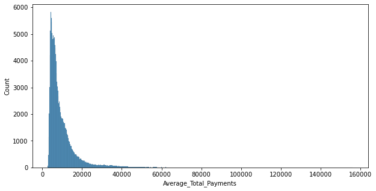

```python
plt.figure(figsize=(10,5)) # Plot a graph with reasonable size.
sns.histplot(data['Average_Total_Payments'])
# plt.plot(data['Average_Total_Payments'])
```

- One plot is enough. The following plot can be omitted.

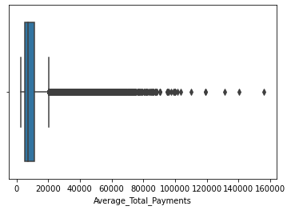

```python
sns.boxplot(x = 'Average_Total_Payments', data = data)
```

### Section 2.2: Count by State

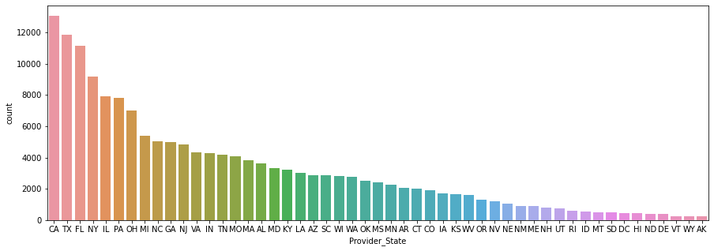

```python
# data['Provider_State'].value_counts()
plt.figure(figsize=(15,5))
sns.countplot(x='Provider_State',data=data,order=data['Provider_State'].value_counts().index)
#plt.xticks(rotation = 90)
#ax = plt.gca()
#for p in ax.patches:
#    ax.text(p.get_x() + p.get_width()/2., p.get_height(), '%d' % int(p.get_height()),
#            fontsize=12, color='blue', ha='center', va='bottom')
plt.rcParams["axes.labelsize"] = 20
```

- From this histogram, California, Texas, and Florid has the highest number of hospital divisions.

### Section 2.3: Count of top 20 cities

```python
data['Provider_Name'].value_counts()
```

```
GOOD SAMARITAN HOSPITAL                  633
ST JOSEPH MEDICAL CENTER                 427
MERCY MEDICAL CENTER                     357
MERCY HOSPITAL                           347
ST JOSEPH HOSPITAL                       343
                                        ...
J PAUL JONES HOSPITAL                      1
GREATER BATON ROUGE SURGICAL HOSPITAL      1
FAIRWAY MEDICAL CENTER                     1
MONROE SURGICAL HOSPITAL                   1
EAGLEVILLE HOSPITAL                        1
Name: Provider_Name, Length: 3201, dtype: int64
```

[output not shown]

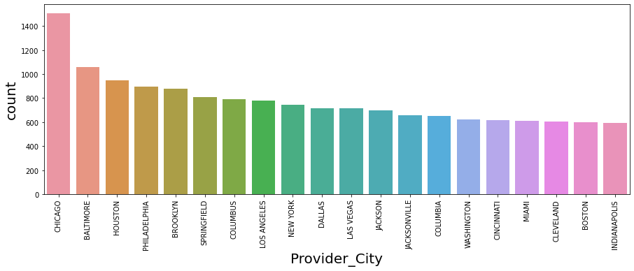

```python
plt.figure(figsize=(15,5))
ch = sns.countplot(x='Provider_City',data=data,order=data['Provider_City'].value_counts()[:20].index)
plt.xticks(rotation = 90)
# junk = ch.set_xticklabels(ch.get_xticklabels()) # Use this line to collect the text prints

#ax = plt.gca()
#plt.rcParams["axes.labelsize"] = 20


# b.set_xlabel("X Label",fontsize=30)
# b.set_ylabel("Y Label",fontsize=20)
# b.tick_params(labelsize=5)

# for p in ax.patches:
#     ax.text(p.get_x() + p.get_width()/2., p.get_height(), '%d' % int(p.get_height()),
#             fontsize=12, color='blue', ha='center', va='bottom')
# plt.rcParams["axes.labelsize"] = 20
```

- The above text are from matplotlib.
- We really do not want to print the text.
- You can assign them to "_" to throw them away.

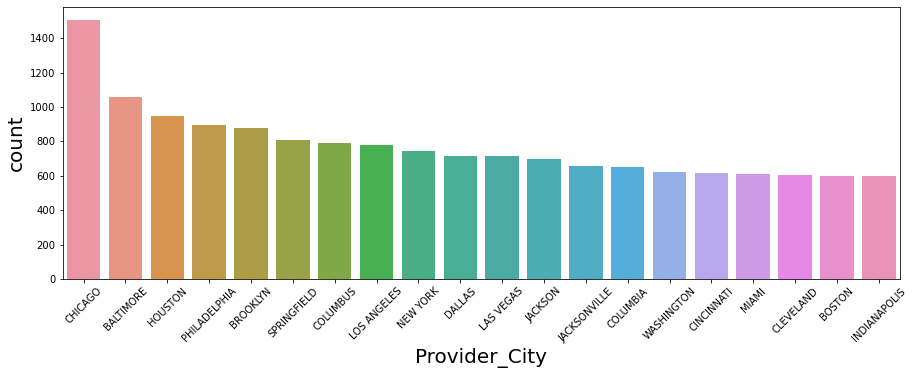

```python
# This will look better
plt.figure(figsize=(15,5))
txt = data['Provider_City'].value_counts()[:20].index

chart = sns.countplot(
    x='Provider_City' ,data=data , order=txt
)

_ = chart.set_xticklabels(chart.get_xticklabels(), rotation=45)
plt.rcParams["axes.labelsize"] = 10
```

#### Class discussion/Thought process:

- The following shows the average medicare payment by DRG. Does it make sense to compare "917 - POISONING & TOXIC EFFECTS OF DRUGS W MCC" with "885 - PSYCHOSES"?

```python
data.groupby('DRG')['Average_Total_Payments'].describe().reset_index().head()
```

|  | DRG | count | mean | std | min | 25% | 50% | 75% | max |
| --- | --- | --- | --- | --- | --- | --- | --- | --- | --- |
| 0 | 039 - EXTRACRANIAL PROCEDURES W/O CC/MCC | 1079.0 | 6960.534004 | 1477.873952 | 4968.00 | 6001.830 | 6582.890 | 7516.825 | 18420.56 |
| 1 | 057 - DEGENERATIVE NERVOUS SYSTEM DISORDERS W/... | 1201.0 | 6706.276445 | 2033.965862 | 4194.09 | 5412.870 | 6093.750 | 7345.360 | 25519.43 |
| 2 | 064 - INTRACRANIAL HEMORRHAGE OR CEREBRAL INFA... | 1659.0 | 13263.823032 | 3847.918207 | 8174.28 | 10762.220 | 12084.700 | 14424.325 | 50882.40 |
| 3 | 065 - INTRACRANIAL HEMORRHAGE OR CEREBRAL INFA... | 2269.0 | 7922.671141 | 2084.658336 | 5368.73 | 6626.270 | 7280.050 | 8503.060 | 26510.15 |
| 4 | 066 - INTRACRANIAL HEMORRHAGE OR CEREBRAL INFA... | 1806.0 | 5713.985221 | 1342.538675 | 3916.41 | 4819.325 | 5326.025 | 6197.480 | 14744.05 |

## Section 3: Feature Engineering

Back to Table of Content

#### Discussions:

- Think of the objective: "Detect any hospital that may abuse the resources compared to the average of its peers of the same DRG and State."
- A feature should be able to "detect any hospital...". The above table does not have hospitals.
- The above table is the benchmark. Are they features?

#### Intuition:

- One or two hospitals may abuse their medical resources. If we compare a transaction to his hospital, we can find outliers.
- The spending for a Diagnosis Related Group (DRG) can be higher than others. It does not make sense to compare the spending of a DRG to another. An state can spend on various DRG, and we cannot claim anomalies just because the spending on one DRG is higher than another.
- So, we will aggregate to the state level and DRG level, then build features.
- Common sense tells us the comparison should be at "Provider_State" and "DRG" levels.

### Section 3.1: Create the benchmark table

#### Section 3.1.1: Average Total Payment by State & DRG

Back to Table of Content

```python
benchmark1 = data.groupby(['Provider_State','DRG'])['Average_Total_Payments'].mean().reset_index()
benchmark1.columns = ['Provider_State','DRG','Avg_Pmts_ByStateDRG']
benchmark1.head()
```

|  | Provider_State | DRG | Avg_Pmts_ByStateDRG |
| --- | --- | --- | --- |
| 0 | AK | 039 - EXTRACRANIAL PROCEDURES W/O CC/MCC | 8401.950000 |
| 1 | AK | 057 - DEGENERATIVE NERVOUS SYSTEM DISORDERS W/... | 8799.000000 |
| 2 | AK | 064 - INTRACRANIAL HEMORRHAGE OR CEREBRAL INFA... | 21608.010000 |
| 3 | AK | 065 - INTRACRANIAL HEMORRHAGE OR CEREBRAL INFA... | 12555.548333 |
| 4 | AK | 066 - INTRACRANIAL HEMORRHAGE OR CEREBRAL INFA... | 9275.867500 |

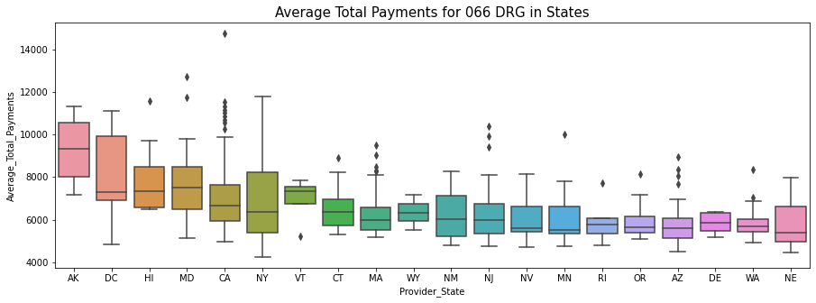

```python
# visualize data with DRG 066 mean grouped by state and DRG ordering by mean descreasing
data_066 = data[data.DRG == '066 - INTRACRANIAL HEMORRHAGE OR CEREBRAL INFARCTION W/O CC/MCC']
df_066_avg_st_drg = data_066.groupby('Provider_State').mean()
sorted_index = df_066_avg_st_drg.sort_values(by='Average_Total_Payments',ascending=False)[:20].index
plt.figure(figsize=(15,5))
sns.boxplot(x="Provider_State", y="Average_Total_Payments",
            order = sorted_index, data=data_066)
plt.title('Average Total Payments for 066 DRG in States',fontsize=15)
```

##### My thought process:

- I filter top 20 states of average total payments for 066 - INTRACRANIAL HEMORRHAGE OR CEREBRAL INFARCTION W/O CC/MCC DRG feature. From the boxplot, Alaska is the highest one with without outliers.
- Each state varies in average total payment of DRG, like outliers, standard deviation etc. Therefore, further anomaly detection in average total payments by state and DRG is necessary.

#### Section 3.1.2: Median Total Payment by State & DRG

Back to Table of Content

```python
benchmark2 = data.groupby(['Provider_State','DRG'])['Average_Total_Payments'].median().reset_index()
benchmark2.columns = ['Provider_State','DRG','Med_Pmts_ByStateDRG']
benchmark2.head()
```

|  | Provider_State | DRG | Med_Pmts_ByStateDRG |
| --- | --- | --- | --- |
| 0 | AK | 039 - EXTRACRANIAL PROCEDURES W/O CC/MCC | 8401.950 |
| 1 | AK | 057 - DEGENERATIVE NERVOUS SYSTEM DISORDERS W/... | 8799.000 |
| 2 | AK | 064 - INTRACRANIAL HEMORRHAGE OR CEREBRAL INFA... | 21608.010 |
| 3 | AK | 065 - INTRACRANIAL HEMORRHAGE OR CEREBRAL INFA... | 12437.045 |
| 4 | AK | 066 - INTRACRANIAL HEMORRHAGE OR CEREBRAL INFA... | 9320.250 |

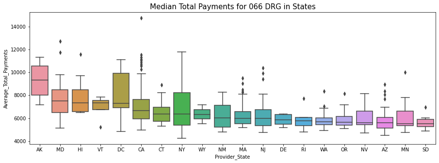

```python
# visualize data with DRG 066 median grouped by state and DRG ordering by median descreasing
data_066 = data[data.DRG == '066 - INTRACRANIAL HEMORRHAGE OR CEREBRAL INFARCTION W/O CC/MCC']
data_066_med_st_rdg = data_066.groupby('Provider_State').median()
sorted_index = data_066_med_st_rdg.sort_values(by='Average_Total_Payments',ascending=False)[:20].index

plt.figure(figsize=(15,5))
sns.boxplot(x="Provider_State", y="Average_Total_Payments",
            order=sorted_index, data=data_066)
plt.title('Median Total Payments for 066 DRG in States',fontsize=15)
```

##### My thought process:

- I filter top 20 states of median total payments for 066 - INTRACRANIAL HEMORRHAGE OR CEREBRAL INFARCTION W/O CC/MCC DRG feature. From the boxplot, Alaska is the highest one with without outliers.
- Each state varies in average total payment of DRG, like outliers, standard deviation etc. Therefore, further anomaly detection in average total payments by state and DRG is necessary.
- Median is better than average when there are outliers, for example extreme values influences average a lot but not median.

#### Section 3.1.3: Average Total Discharges by State & DRG

Back to Table of Content

```python
benchmark3 = data.groupby(['Provider_State','DRG'])['Total_Discharges'].\
                            mean().reset_index()
benchmark3.columns = ['Provider_State','DRG','Avg_Dischs_ByStateDRG']
benchmark3.sort_values(['Avg_Dischs_ByStateDRG']).head()
```

|  | Provider_State | DRG | Avg_Dischs_ByStateDRG |
| --- | --- | --- | --- |
| 4197 | SD | 917 - POISONING & TOXIC EFFECTS OF DRUGS W MCC | 11.0 |
| 64 | AK | 419 - LAPAROSCOPIC CHOLECYSTECTOMY W/O C.D.E. ... | 11.0 |
| 5060 | WY | 391 - ESOPHAGITIS, GASTROENT & MISC DIGEST DIS... | 11.0 |
| 1174 | HI | 536 - FRACTURES OF HIP & PELVIS W/O MCC | 11.0 |
| 72 | AK | 482 - HIP & FEMUR PROCEDURES EXCEPT MAJOR JOIN... | 11.0 |

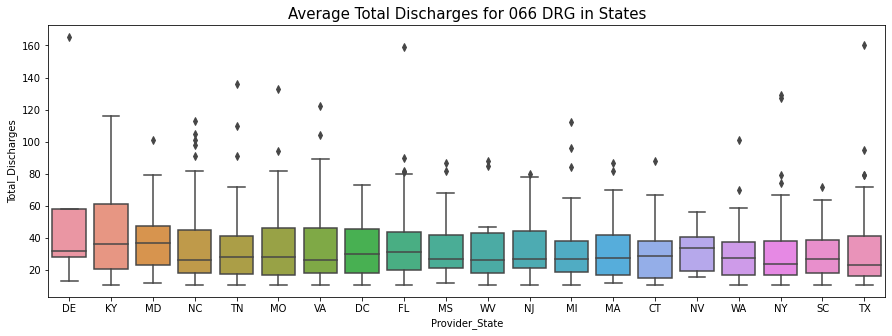

```python
# visualize data with DRG 066 mean grouped by state and total discharges ordering by mean descreasing
data_066 = data[data.DRG == '066 - INTRACRANIAL HEMORRHAGE OR CEREBRAL INFARCTION W/O CC/MCC']
data_066_avg_ct_td = data_066.groupby('Provider_State').mean()
sorted_index = data_066_avg_ct_td.sort_values(by='Total_Discharges',ascending=False)[:20].index

plt.figure(figsize=(15,5))
sns.boxplot(x="Provider_State", y="Total_Discharges",
            order=sorted_index, data=data_066)
plt.title('Average Total Discharges for 066 DRG in States',fontsize=15)
```

#### Section 3.1.4: Median Total Discharges by State & DRG

Back to Table of Content

```python
benchmark4 = data.groupby(['Provider_State','DRG'])['Total_Discharges'].\
                            median().reset_index()
benchmark4.columns = ['Provider_State','DRG','Med_Dischs_ByStateDRG']
benchmark4.sort_values(['Med_Dischs_ByStateDRG']).head()
```

|  | Provider_State | DRG | Med_Dischs_ByStateDRG |
| --- | --- | --- | --- |
| 4477 | UT | 602 - CELLULITIS W MCC | 11.0 |
| 31 | AK | 253 - OTHER VASCULAR PROCEDURES W CC | 11.0 |
| 4408 | UT | 149 - DYSEQUILIBRIUM | 11.0 |
| 2663 | MT | 418 - LAPAROSCOPIC CHOLECYSTECTOMY W/O C.D.E. ... | 11.0 |
| 1188 | HI | 699 - OTHER KIDNEY & URINARY TRACT DIAGNOSES W CC | 11.0 |

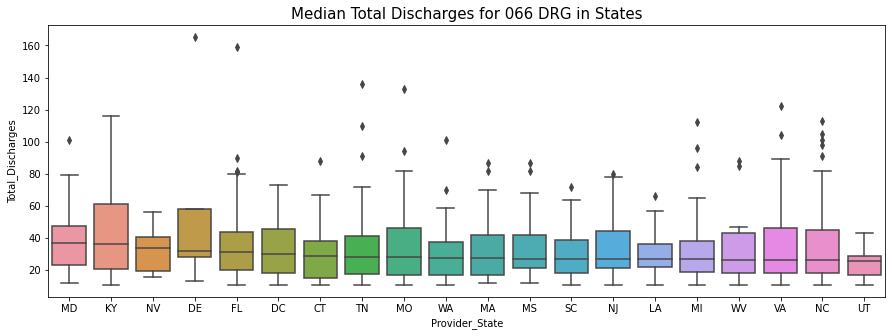

```python
# visualize data with DRG 066 median grouped by state and total discharges ordering by mean descreasing
data_066 = data[data.DRG == '066 - INTRACRANIAL HEMORRHAGE OR CEREBRAL INFARCTION W/O CC/MCC']
data_066_avg_ct_td = data_066.groupby('Provider_State').median()
sorted_index = data_066_avg_ct_td.sort_values(by='Total_Discharges',ascending=False)[:20].index

plt.figure(figsize=(15,5))
sns.boxplot(x="Provider_State", y="Total_Discharges",
            order=sorted_index, data=data_066)
plt.title('Median Total Discharges for 066 DRG in States',fontsize=15)
```

#### Section 3.1.5: Average Medicare Payments by State & DRG

Back to Table of Content

##### My thought process:

- I filter top 20 states of median total payments for 066 - INTRACRANIAL HEMORRHAGE OR CEREBRAL INFARCTION W/O CC/MCC DRG feature. From the boxplot, Maryland is the highest state.
- Each state varies in average total payment of DRG, like outliers, standard deviation etc. Therefore, further anomaly detection in average total discharges by state and DRG is necessary.
- Median is better than average when there are outliers, for example extreme values influences average a lot but not median.

```python
benchmark5 = data.groupby(['Provider_State','DRG'])['Average_Medicare_Payment'].\
                            mean().reset_index()
benchmark5.columns = ['Provider_State','DRG','Avg_Medi_ByStateDRG']
benchmark5.head()
```

|  | Provider_State | DRG | Avg_Medi_ByStateDRG |
| --- | --- | --- | --- |
| 0 | AK | 039 - EXTRACRANIAL PROCEDURES W/O CC/MCC | 6413.780000 |
| 1 | AK | 057 - DEGENERATIVE NERVOUS SYSTEM DISORDERS W/... | 8081.540000 |
| 2 | AK | 064 - INTRACRANIAL HEMORRHAGE OR CEREBRAL INFA... | 20555.255000 |
| 3 | AK | 065 - INTRACRANIAL HEMORRHAGE OR CEREBRAL INFA... | 11140.963333 |
| 4 | AK | 066 - INTRACRANIAL HEMORRHAGE OR CEREBRAL INFA... | 8258.427500 |

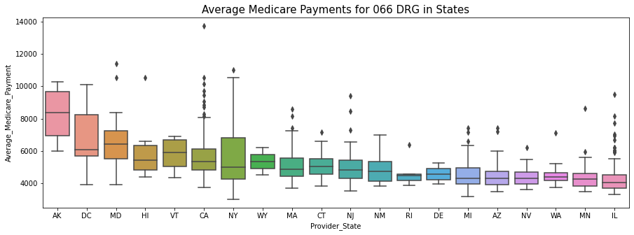

```python
# visualize data with DRG 066 mean grouped by state and total discharges ordering by mean descreasing
data_066 = data[data.DRG == '066 - INTRACRANIAL HEMORRHAGE OR CEREBRAL INFARCTION W/O CC/MCC']
data_066_avg_ct_td = data_066.groupby('Provider_State').mean()
sorted_index = data_066_avg_ct_td.sort_values(by='Average_Medicare_Payment',ascending=False)[:20].index

plt.figure(figsize=(15,5))
sns.boxplot(x="Provider_State", y="Average_Medicare_Payment",
            order=sorted_index, data=data_066)
plt.title('Average Medicare Payments for 066 DRG in States',fontsize=15)
```

#### Section 3.1.6: Median Medicare Payments by State & DRG

Back to Table of Content

```python
benchmark6 = data.groupby(['Provider_State','DRG'])['Average_Medicare_Payment'].\
                            median().reset_index()
benchmark6.columns = ['Provider_State','DRG','Med_Medi_ByStateDRG']
benchmark6.sort_values(['Med_Medi_ByStateDRG']).head()
```

|  | Provider_State | DRG | Med_Medi_ByStateDRG |
| --- | --- | --- | --- |
| 149 | AL | 313 - CHEST PAIN | 2127.920 |
| 1649 | KS | 313 - CHEST PAIN | 2157.330 |
| 147 | AL | 310 - CARDIAC ARRHYTHMIA & CONDUCTION DISORDER... | 2174.940 |
| 1249 | IA | 313 - CHEST PAIN | 2206.265 |
| 249 | AR | 313 - CHEST PAIN | 2219.145 |

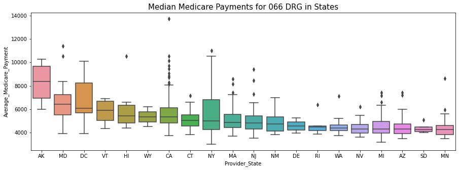

```python
# visualize data with DRG 066 median grouped by state and total discharges ordering by mean descreasing
data_066 = data[data.DRG == '066 - INTRACRANIAL HEMORRHAGE OR CEREBRAL INFARCTION W/O CC/MCC']
data_066_med_st_drg = data_066.groupby('Provider_State').median()
sorted_index = data_066_med_st_drg.sort_values(by='Average_Medicare_Payment',ascending=False)[:20].index

plt.figure(figsize=(15,5))
sns.boxplot(x="Provider_State", y="Average_Medicare_Payment",
            order=sorted_index, data=data_066)
plt.title('Median Medicare Payments for 066 DRG in States',fontsize=15)
```

##### My thought process:

- I filter top 20 states of median medicare payments for 066 - INTRACRANIAL HEMORRHAGE OR CEREBRAL INFARCTION W/O CC/MCC DRG feature. From the boxplot, Alaska is the highest one without outliers.
- Each state varies in average total payment of DRG, like outliers, standard deviation etc. Therefore, further anomaly detection in average medicare payment by state and DRG is necessary.
- Median is better than average when there are outliers, for example extreme values influences average a lot but not median.

#### Section 3.1.7: Average Total Payments by Region & DRG

Back to Table of Content

```python
benchmark7 = data.groupby(['Hospital_referral_region_desp','DRG'])['Average_Total_Payments'].\
                            mean().reset_index()
benchmark7.columns = ['Hospital_referral_region_desp','DRG','Avg_Pmts_ByRegionDRG']
benchmark7.sort_values(['Avg_Pmts_ByRegionDRG']).head()
```

|  | Hospital_referral_region_desp | DRG | Avg_Pmts_ByRegionDRG |
| --- | --- | --- | --- |
| 8149 | IA - Dubuque | 313 - CHEST PAIN | 2944.0200 |
| 6649 | FL - Sarasota | 313 - CHEST PAIN | 2987.1675 |
| 27443 | TX - Waco | 303 - ATHEROSCLEROSIS W/O MCC | 3017.0000 |
| 6149 | FL - Ocala | 313 - CHEST PAIN | 3021.9850 |
| 8147 | IA - Dubuque | 310 - CARDIAC ARRHYTHMIA & CONDUCTION DISORDER... | 3055.0500 |

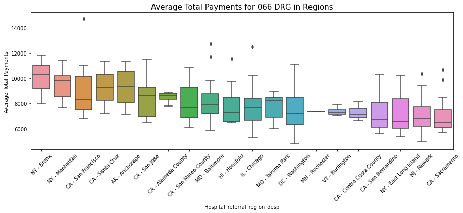

```python
# visualize data with DRG 066 mean grouped by state and total discharges ordering by mean descreasing
data_066 = data[data.DRG == '066 - INTRACRANIAL HEMORRHAGE OR CEREBRAL INFARCTION W/O CC/MCC']
data_066_avg_ct_td = data_066.groupby('Hospital_referral_region_desp').mean()
sorted_index = data_066_avg_ct_td.sort_values(by='Average_Total_Payments',ascending=False)[:20].index

plt.figure(figsize=(15,5))

g = sns.boxplot(x="Hospital_referral_region_desp", y="Average_Total_Payments",
            order=sorted_index, data=data_066)
g.set_xticklabels(g.get_xticklabels(), rotation=45)
plt.title('Average Total Payments for 066 DRG in Regions',fontsize=15)
```

##### My thought process:

- I filter top 20 hospital referral region desp of average total payments for 066 - INTRACRANIAL HEMORRHAGE OR CEREBRAL INFARCTION W/O CC/MCC DRG feature. From the boxplot, NY-Bronx is the highest one without outliers.
- Each region varies in average total payment of DRG, like outliers, standard deviation etc. Therefore, further anomaly detection in average total payment by region and DRG is necessary.

#### Section 3.1.8: Average Total Discharges by Region & DRG

Back to Table of Content

```python
benchmark8 = data.groupby(['Hospital_referral_region_desp','DRG'])['Total_Discharges'].\
                            mean().reset_index()
benchmark8.columns = ['Hospital_referral_region_desp','DRG','Tot_Dischs_ByRegionDRG']
benchmark8.sort_values(['Tot_Dischs_ByRegionDRG']).head()
```

|  | Hospital_referral_region_desp | DRG | Tot_Dischs_ByRegionDRG |
| --- | --- | --- | --- |
| 3842 | CA - Stockton | 301 - PERIPHERAL VASCULAR DISORDERS W/O CC/MCC | 11.0 |
| 6719 | FL - St. Petersburg | 202 - BRONCHITIS & ASTHMA W CC/MCC | 11.0 |
| 7801 | IA - Cedar Rapids | 057 - DEGENERATIVE NERVOUS SYSTEM DISORDERS W/... | 11.0 |
| 29676 | WI - La Crosse | 563 - FX, SPRN, STRN & DISL EXCEPT FEMUR, HIP,... | 11.0 |
| 16523 | MS - Oxford | 238 - MAJOR CARDIOVASC PROCEDURES W/O MCC | 11.0 |

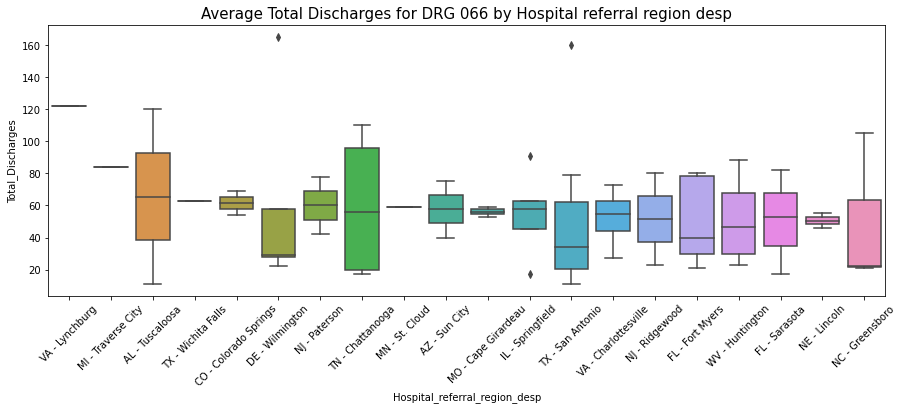

```python
# visualize data with DRG 066 mean grouped by state and total discharges ordering by mean descreasing
data_066 = data[data.DRG == '066 - INTRACRANIAL HEMORRHAGE OR CEREBRAL INFARCTION W/O CC/MCC']
data_066_avg_ct_td = data_066.groupby('Hospital_referral_region_desp').mean()
sorted_index = data_066_avg_ct_td.sort_values(by='Total_Discharges',ascending=False)[:20].index

plt.figure(figsize=(15,5))

g = sns.boxplot(x="Hospital_referral_region_desp", y="Total_Discharges",
            order=sorted_index, data=data_066)
g.set_xticklabels(g.get_xticklabels(), rotation=45)
plt.title('Average Total Discharges for DRG 066 by Hospital referral region desp',fontsize=15)
```

##### My thought process:

- I filter top 20 hospital referral region desp of average total discharges for 066 - INTRACRANIAL HEMORRHAGE OR CEREBRAL INFARCTION W/O CC/MCC DRG feature. From the boxplot, VA-Lychburg is the highest one, and its distribution is very condensed.
- Each region varies in average total discharges of DRG, like outliers, standard deviation etc. Therefore, further anomaly detection in average total payment by region and DRG is necessary.

#### Section 3.1.9: Average Medicare Payments by Region & DRG

Back to Table of Content

```python
benchmark9 = data.groupby(['Hospital_referral_region_desp','DRG'])['Average_Medicare_Payment'].\
                            mean().reset_index()
benchmark9.columns = ['Hospital_referral_region_desp','DRG','Avg_Medi_Payment_ByRegionDRG']
benchmark9.sort_values(['Avg_Medi_Payment_ByRegionDRG']).head()
```

|  | Hospital_referral_region_desp | DRG | Avg_Medi_Payment_ByRegionDRG |
| --- | --- | --- | --- |
| 8149 | IA - Dubuque | 313 - CHEST PAIN | 1811.240 |
| 10544 | IN - Lafayette | 305 - HYPERTENSION W/O MCC | 1855.070 |
| 6520 | FL - Pensacola | 203 - BRONCHITIS & ASTHMA W/O CC/MCC | 1858.780 |
| 5220 | FL - Bradenton | 203 - BRONCHITIS & ASTHMA W/O CC/MCC | 1940.680 |
| 6149 | FL - Ocala | 313 - CHEST PAIN | 1942.905 |

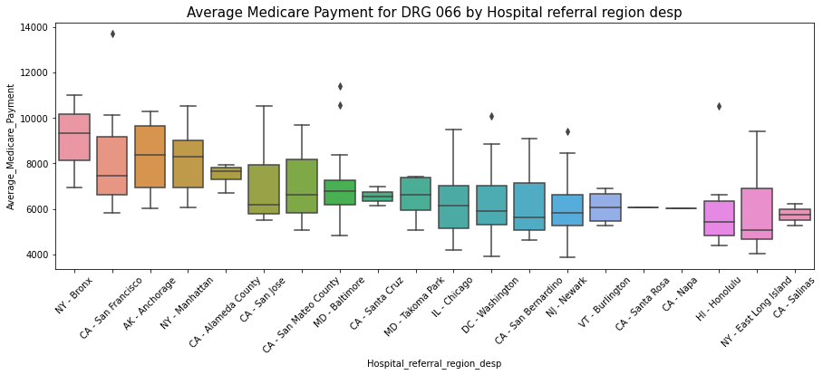

```python
# visualize data with DRG 066 mean grouped by state and total discharges ordering by mean descreasing
data_066 = data[data.DRG == '066 - INTRACRANIAL HEMORRHAGE OR CEREBRAL INFARCTION W/O CC/MCC']
data_066_avg_ct_td = data_066.groupby('Hospital_referral_region_desp').mean()
sorted_index = data_066_avg_ct_td.sort_values(by='Average_Medicare_Payment',ascending=False)[:20].index

plt.figure(figsize=(15,5))

g = sns.boxplot(x="Hospital_referral_region_desp", y="Average_Medicare_Payment",
            order=sorted_index, data=data_066)
g.set_xticklabels(g.get_xticklabels(), rotation=45)
plt.title('Average Medicare Payment for DRG 066 by Hospital referral region desp',fontsize=15)
```

##### My thought process:

- I filter top 20 hospital referral region desp of average medicare payments for 066 - INTRACRANIAL HEMORRHAGE OR CEREBRAL INFARCTION W/O CC/MCC DRG feature. From the boxplot, NY-Bronx is the highest one without outliers.
- Each region varies in average total discharges of DRG, like outliers, standard deviation etc. Therefore, further anomaly detection in average total payment by region and DRG is necessary.

#### Section 3.1.10: Average Total Payments by Region & DRG

Back to Table of Content

```python
data['Total_Payments'] = data['Average_Total_Payments'] * data['Total_Discharges']
benchmark10 = data.groupby(['Hospital_referral_region_desp','DRG'])['Total_Payments'].\
                            mean().reset_index()
benchmark10.columns = ['Hospital_referral_region_desp','DRG','Tot_Pmts_ByRegionDRG']
benchmark10.sort_values(['Tot_Pmts_ByRegionDRG']).head()
```

|  | Hospital_referral_region_desp | DRG | Tot_Pmts_ByRegionDRG |
| --- | --- | --- | --- |
| 12144 | LA - Lake Charles | 305 - HYPERTENSION W/O MCC | 35513.94 |
| 27443 | TX - Waco | 303 - ATHEROSCLEROSIS W/O MCC | 36204.00 |
| 22796 | PA - Danville | 897 - ALCOHOL/DRUG ABUSE OR DEPENDENCE W/O REH... | 36483.92 |
| 8157 | IA - Dubuque | 379 - G.I. HEMORRHAGE W/O CC/MCC | 36670.92 |
| 15620 | MO - Columbia | 203 - BRONCHITIS & ASTHMA W/O CC/MCC | 37229.94 |

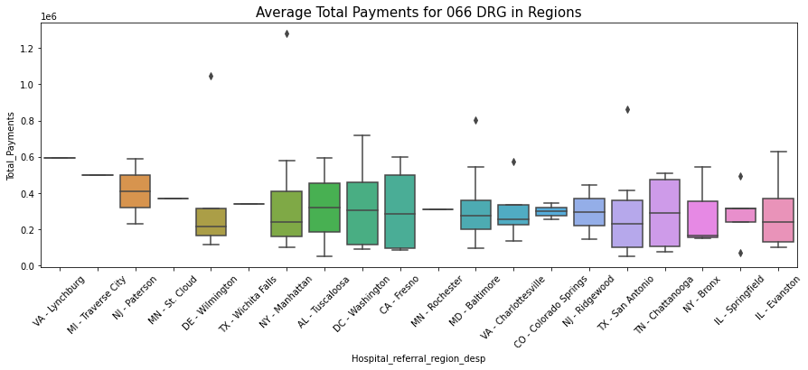

```python
# visualize data with DRG 066 mean grouped by state and total discharges ordering by mean descreasing
data_066 = data[data.DRG == '066 - INTRACRANIAL HEMORRHAGE OR CEREBRAL INFARCTION W/O CC/MCC']
data_066_avg_ct_td = data_066.groupby('Hospital_referral_region_desp').mean()
sorted_index = data_066_avg_ct_td.sort_values(by='Total_Payments',ascending=False)[:20].index

plt.figure(figsize=(15,5))

g = sns.boxplot(x="Hospital_referral_region_desp", y="Total_Payments",
            order=sorted_index, data=data_066)
g.set_xticklabels(g.get_xticklabels(), rotation=45)
plt.title('Average Total Payments for 066 DRG in Regions',fontsize=15)
```

##### My thought process:

- I filter top 20 hospital referral region desp of average total payments for 066 - INTRACRANIAL HEMORRHAGE OR CEREBRAL INFARCTION W/O CC/MCC DRG feature. From the boxplot, VA-Lynchburg is the highest, and its data is very condensed.
- Each region varies in total payment of DRG, like outliers, standard deviation etc. Therefore, further anomaly detection in total payment by region and DRG is necessary.

### Section 3.2: Create features

#### Intuition:

- One or two hospitals may abuse the medical system. If we compare a hospitals to their state, we can find outliers.
- The spending for a DRG can be higher than others. It does not make sense to compare the spending of a Diagnosis Related Group (DRG) to another. An state can spend on DRG, and we cannot claim anomalies just because the spending on one DRG is higher than another since different states have various dissimilarities, including policies, economy etc.
- So, we will aggregate to the state level and DRG level, then build features.
- Common sense tells us the comparison should be at "Provider_State" and "DRG" levels.

#### 3.2.1 Feature 1: The ratio to average payment by state and DRG

Back to Table of Content

##### My thought process:

- The ratio to average payment by state and DRG is a good feature since hospitals which share the state and DRG are more likely to similar level of medical expense. If the ratio to average amount of hospitals way above the average, we should check if it is anomolies.

```python
# add the new feature average spending to the dataset
df1 = pd.merge(data, benchmark1, how='left', on=['Provider_State', 'DRG'])
# Feature 1: ratio of amount spending and avergae spending by state and DRG
df1['state_drg_avg_ratio_amount'] = np.where(df1['Avg_Pmts_ByStateDRG']==0, 0, df1['Average_Total_Payments'] / df1['Avg_Pmts_ByStateDRG'])
df1['state_drg_avg_ratio_amount'].describe()
```

```
count    163065.000000
mean          1.000000
std           0.195274
min           0.384805
25%           0.880824
50%           0.956830
75%           1.064688
max           7.857934
Name: state_drg_avg_ratio_amount, dtype: float64
```

##### My thought process:

- The above percentile motivates me to cut by percentile for plotting
- I set the percentile as [0,0.01,0.05,0.2,0.5,0.8,0.95,0.99,1].

```python
# cut by percentile for plotting
var = 'state_drg_avg_ratio_amount'
binned_var = var + '_D'
percentile = [0,0.01,0.05,0.2,0.5,0.8,0.95,0.99,1]
df1[binned_var] = pd.qcut(df1[var], percentile)
df1[['state_drg_avg_ratio_amount_D']]
```

|  | state_drg_avg_ratio_amount_D |
| --- | --- |
| 0 | (0.957, 1.102] |
| 1 | (0.957, 1.102] |
| 2 | (0.864, 0.957] |
| 3 | (0.864, 0.957] |
| 4 | (0.957, 1.102] |
| ... | ... |
| 163060 | (0.785, 0.864] |
| 163061 | (0.864, 0.957] |
| 163062 | (1.102, 1.383] |
| 163063 | (1.383, 1.663] |
| 163064 | (0.694, 0.785] |

163065 rows × 1 columns

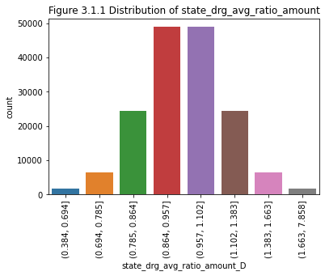

```python
# Plot the distribution
import matplotlib.pyplot as plt
plt.figure(figsize=(6,4))
g = sns.countplot(x='state_drg_avg_ratio_amount_D', data=df1)
g.set_xticklabels(g.get_xticklabels(), rotation=90)
plt.title('Figure 3.1.1 Distribution of state_drg_avg_ratio_amount')
```

##### My thought process:

- Now we have identified extreme spending compared to the same state and DRG.
- If the transactions are 2 times of the average, it should be anomalies since we can see from above description that standard deviation is high. Furthermore, the distribution plt indicates that there are a few in the far end. Therefore, above the 2 times of the average should be monitor to identified whether it is anomalies.

```python
df1[df1['state_drg_avg_ratio_amount']>2].head()
```

|  | DRG | Provider_Id | Provider_Name | Provider_StreetAddress | Provider_City | Provider_State | Provider_Zipcode | Hospital_referral_region_desp | Total_Discharges | Average_Total_Payments | Average_Medicare_Payment | Total_Payments | Avg_Pmts_ByStateDRG | state_drg_avg_ratio_amount | state_drg_avg_ratio_amount_D |
| --- | --- | --- | --- | --- | --- | --- | --- | --- | --- | --- | --- | --- | --- | --- | --- |
| 280 | 039 - EXTRACRANIAL PROCEDURES W/O CC/MCC | 140008 | LOYOLA GOTTLIEB MEMORIAL HOSPITAL | 701 WEST NORTH AVE | MELROSE PARK | IL | 60160 | IL - Melrose Park | 16 | 18420.56 | 4401.87 | 294728.96 | 7376.789808 | 2.497097 | (1.663, 7.858] |
| 294 | 039 - EXTRACRANIAL PROCEDURES W/O CC/MCC | 140080 | RHC ST FRANCIS HOSPITAL | 355 RIDGE AVE | EVANSTON | IL | 60202 | IL - Evanston | 12 | 17347.00 | 6934.08 | 208164.00 | 7376.789808 | 2.351565 | (1.663, 7.858] |
| 1172 | 057 - DEGENERATIVE NERVOUS SYSTEM DISORDERS W/... | 50276 | CONTRA COSTA REGIONAL MEDICAL CENTER | 2500 ALHAMBRA AVE | MARTINEZ | CA | 94553 | CA - Contra Costa County | 23 | 19239.30 | 18363.08 | 442503.90 | 8528.764103 | 2.255813 | (1.663, 7.858] |
| 1191 | 057 - DEGENERATIVE NERVOUS SYSTEM DISORDERS W/... | 50441 | STANFORD HOSPITAL | 300 PASTEUR DRIVE | STANFORD | CA | 94305 | CA - San Mateo County | 16 | 25519.43 | 22553.56 | 408310.88 | 8528.764103 | 2.992160 | (1.663, 7.858] |
| 1258 | 057 - DEGENERATIVE NERVOUS SYSTEM DISORDERS W/... | 100022 | JACKSON MEMORIAL HOSPITAL | 1611 NW 12TH AVE | MIAMI | FL | 33136 | FL - Miami | 29 | 12789.27 | 11467.62 | 370888.83 | 5715.700980 | 2.237568 | (1.663, 7.858] |

##### Conclusion:

- This feature identifies the anomalies by comparing a payment amount to an average amount of same the state and DGR. Here, those amounts more than 2 times the average are determined to be the anomalies, and potential frauds.

#### Feature 2: The ratio to median payment by state and DRG

Back to Table of Content

##### My thought process:

- The ratio to median payment by state and DRG is a good feature since hospitals which share the state and DRG are more likely to similar level of medical expense. Median is also crucial because average can be highly influenced by a small portion of extreme high or low value. If the ratio to median amount of hospitals way above the median, we should check if it is anomolies.

```python
# add the new feature average spending to the dataset
df2 = pd.merge(data, benchmark2, how='left', on=['Provider_State', 'DRG'])
# Feature 1: ratio of amount spending and avergae spending by state and DRG
df2['state_drg_med_ratio_amount'] = np.where(df2['Med_Pmts_ByStateDRG']==0, 0, df2['Average_Total_Payments'] / df2['Med_Pmts_ByStateDRG'])
df2['state_drg_med_ratio_amount'].describe()
```

```
count    163065.000000
mean          1.050746
std           0.211465
min           0.517695
25%           0.925511
50%           1.000000
75%           1.112126
max           9.338775
Name: state_drg_med_ratio_amount, dtype: float64
```

##### My thought process:

- The above percentile motivates me to cut by percentile for plotting
- I set the percentile as [0,0.01,0.05,0.2,0.5,0.8,0.95,0.99,1].

```python
# cut by percentile for plotting
var = 'state_drg_med_ratio_amount'
binned_var = var + '_D'
percentile = [0,0.01,0.05,0.2,0.5,0.8,0.95,0.99,1]
df2[binned_var] = pd.qcut(df2[var], percentile)
df2[['state_drg_med_ratio_amount_D']]
```

|  | state_drg_med_ratio_amount_D |
| --- | --- |
| 0 | (1.0, 1.153] |
| 1 | (1.0, 1.153] |
| 2 | (0.908, 1.0] |
| 3 | (0.908, 1.0] |
| 4 | (0.908, 1.0] |
| ... | ... |
| 163060 | (0.83, 0.908] |
| 163061 | (0.908, 1.0] |
| 163062 | (1.153, 1.466] |
| 163063 | (1.466, 1.79] |
| 163064 | (0.75, 0.83] |

163065 rows × 1 columns

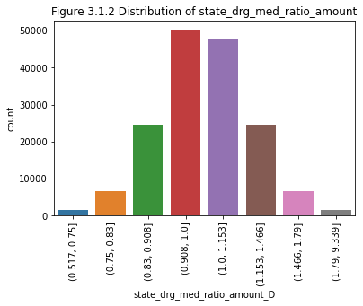

```python
# Plot the distribution
import matplotlib.pyplot as plt
plt.figure(figsize=(6,4))
g = sns.countplot(x='state_drg_med_ratio_amount_D', data=df2)
g.set_xticklabels(g.get_xticklabels(), rotation=90)
plt.title('Figure 3.1.2 Distribution of state_drg_med_ratio_amount')
```

##### Thought process:

- Now, we have identified extreme spending compared to the same state and DRG.
- The ratio of amount spending and median amount by state and DRG category larger than 2 times of the median can be anomalies.

```python
df2[df2['state_drg_med_ratio_amount']>2].head()
```

|  | DRG | Provider_Id | Provider_Name | Provider_StreetAddress | Provider_City | Provider_State | Provider_Zipcode | Hospital_referral_region_desp | Total_Discharges | Average_Total_Payments | Average_Medicare_Payment | Total_Payments | Med_Pmts_ByStateDRG | state_drg_med_ratio_amount | state_drg_med_ratio_amount_D |
| --- | --- | --- | --- | --- | --- | --- | --- | --- | --- | --- | --- | --- | --- | --- | --- |
| 104 | 039 - EXTRACRANIAL PROCEDURES W/O CC/MCC | 50334 | SALINAS VALLEY MEMORIAL HOSPITAL | 450 EAST ROMIE LANE | SALINAS | CA | 93901 | CA - Salinas | 17 | 16744.82 | 7051.05 | 284661.94 | 7863.140 | 2.129533 | (1.79, 9.339] |
| 280 | 039 - EXTRACRANIAL PROCEDURES W/O CC/MCC | 140008 | LOYOLA GOTTLIEB MEMORIAL HOSPITAL | 701 WEST NORTH AVE | MELROSE PARK | IL | 60160 | IL - Melrose Park | 16 | 18420.56 | 4401.87 | 294728.96 | 6673.575 | 2.760224 | (1.79, 9.339] |
| 294 | 039 - EXTRACRANIAL PROCEDURES W/O CC/MCC | 140080 | RHC ST FRANCIS HOSPITAL | 355 RIDGE AVE | EVANSTON | IL | 60202 | IL - Evanston | 12 | 17347.00 | 6934.08 | 208164.00 | 6673.575 | 2.599356 | (1.79, 9.339] |
| 1172 | 057 - DEGENERATIVE NERVOUS SYSTEM DISORDERS W/... | 50276 | CONTRA COSTA REGIONAL MEDICAL CENTER | 2500 ALHAMBRA AVE | MARTINEZ | CA | 94553 | CA - Contra Costa County | 23 | 19239.30 | 18363.08 | 442503.90 | 7689.050 | 2.502169 | (1.79, 9.339] |
| 1191 | 057 - DEGENERATIVE NERVOUS SYSTEM DISORDERS W/... | 50441 | STANFORD HOSPITAL | 300 PASTEUR DRIVE | STANFORD | CA | 94305 | CA - San Mateo County | 16 | 25519.43 | 22553.56 | 408310.88 | 7689.050 | 3.318931 | (1.79, 9.339] |

##### Conclusion:

- This feature identifies the anomalies by comparing a transaction amount to a median amount at the state and DRG level. Here, these amounts which are more than 2 times of the median are determined to be the anomalies, and potential frauds.

#### 3.2.3 Feature 3: The ratio to total discharges by state and DRG

Back to Table of Content

##### My thought process:

```python
# add the new feature average spending to the dataset
df3 = pd.merge(data, benchmark3, how='left', on=['Provider_State', 'DRG'])
# Feature 3: ratio of amount spending and avergae spending by state and total discharges
df3['st_td_avg_ratio_amount'] = np.where(df3['Avg_Dischs_ByStateDRG']==0, 0, df3['Average_Medicare_Payment'] / df3['Avg_Dischs_ByStateDRG'])
df3['st_td_avg_ratio_amount'] = df3['st_td_avg_ratio_amount'].fillna(-1)
df3['st_td_avg_ratio_amount'].describe()
```

```
count    163065.000000
mean        267.913400
std         311.044960
min          10.605349
25%         101.826118
50%         169.378365
75%         307.879820
max        8083.787595
Name: st_td_avg_ratio_amount, dtype: float64
```

##### My thought process:

- The above percentile motivates me to cut by percentile for plotting
- I set the percentile as [0,0.01,0.05,0.2,0.5,0.8,0.95,0.99,1].

```python
# cut by percentile for plotting
var = 'st_td_avg_ratio_amount'
binned_var = var + '_D'
percentile = [0,0.01,0.05,0.2,0.5,0.8,0.95,0.99,1]
df3[binned_var] = pd.qcut(df3[var],percentile)
df3[['st_td_avg_ratio_amount_D']]
```

|  | st_td_avg_ratio_amount_D |
| --- | --- |
| 0 | (90.957, 169.378] |
| 1 | (90.957, 169.378] |
| 2 | (90.957, 169.378] |
| 3 | (90.957, 169.378] |
| 4 | (90.957, 169.378] |
| ... | ... |
| 163060 | (90.957, 169.378] |
| 163061 | (90.957, 169.378] |
| 163062 | (90.957, 169.378] |
| 163063 | (169.378, 356.29] |
| 163064 | (90.957, 169.378] |

163065 rows × 1 columns

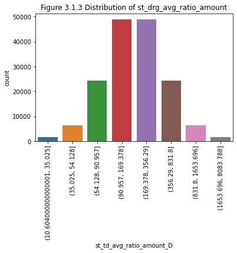

```python
# Plot the distribution
import matplotlib.pyplot as plt
plt.figure(figsize=(6,4))
g = sns.countplot(x='st_td_avg_ratio_amount_D', data=df3)
g.set_xticklabels(g.get_xticklabels(), rotation=90)
plt.title('Figure 3.1.3 Distribution of st_drg_avg_ratio_amount')
```

##### Thought process:

```python
df3[df3['st_td_avg_ratio_amount']>830].head()
```

|  | DRG | Provider_Id | Provider_Name | Provider_StreetAddress | Provider_City | Provider_State | Provider_Zipcode | Hospital_referral_region_desp | Total_Discharges | Average_Total_Payments | Average_Medicare_Payment | Total_Payments | Avg_Dischs_ByStateDRG | st_td_avg_ratio_amount | st_td_avg_ratio_amount_D |
| --- | --- | --- | --- | --- | --- | --- | --- | --- | --- | --- | --- | --- | --- | --- | --- |
| 1172 | 057 - DEGENERATIVE NERVOUS SYSTEM DISORDERS W/... | 50276 | CONTRA COSTA REGIONAL MEDICAL CENTER | 2500 ALHAMBRA AVE | MARTINEZ | CA | 94553 | CA - Contra Costa County | 23 | 19239.30 | 18363.08 | 442503.90 | 18.833333 | 975.030796 | (831.8, 1653.696] |
| 1191 | 057 - DEGENERATIVE NERVOUS SYSTEM DISORDERS W/... | 50441 | STANFORD HOSPITAL | 300 PASTEUR DRIVE | STANFORD | CA | 94305 | CA - San Mateo County | 16 | 25519.43 | 22553.56 | 408310.88 | 18.833333 | 1197.534159 | (831.8, 1653.696] |
| 2319 | 064 - INTRACRANIAL HEMORRHAGE OR CEREBRAL INFA... | 20012 | FAIRBANKS MEMORIAL HOSPITAL | 1650 COWLES STREET | FAIRBANKS | AK | 99701 | AK - Anchorage | 11 | 25443.00 | 24413.90 | 279873.00 | 22.500000 | 1085.062222 | (831.8, 1653.696] |
| 2428 | 064 - INTRACRANIAL HEMORRHAGE OR CEREBRAL INFA... | 50228 | SAN FRANCISCO GENERAL HOSPITAL | 1001 POTRERO AVENUE | SAN FRANCISCO | CA | 94110 | CA - San Francisco | 19 | 35275.57 | 34455.00 | 670235.83 | 31.878788 | 1080.812738 | (831.8, 1653.696] |
| 2461 | 064 - INTRACRANIAL HEMORRHAGE OR CEREBRAL INFA... | 50348 | UNIVERSITY OF CALIFORNIA IRVINE MED CENTER | 101 CITY DRIVE SOUTH | ORANGE | CA | 92868 | CA - Orange County | 26 | 33918.23 | 33054.88 | 881873.98 | 31.878788 | 1036.892624 | (831.8, 1653.696] |

#### Feature 4: The ratio to median total discharges by state and DRG

Back to Table of Content

##### My thought process:

- The ratio to median total discharges by state and DRG is a good feature since hospitals which share the state and DRG are more likely to similar level of medical expense. Median is also crucial because average can be highly influenced by a small portion of extreme high or low value. If the ratio to median amount of hospitals way above the median, we should check if it is anomolies.

```python
# add the new feature average spending to the dataset
df4 = pd.merge(data, benchmark4, how='left', on=['Provider_State', 'DRG'])
# # Feature 4: ratio of amount spending and median spending by state and total discharges
df4['st_td_med_ratio_amount'] = np.where(df4['Med_Dischs_ByStateDRG']==0, 0, df4['Total_Discharges'] / df4['Med_Dischs_ByStateDRG'])
df4['st_td_med_ratio_amount'].describe()
```

```
count    163065.000000
mean          1.260075
std           0.987288
min           0.047210
25%           0.687500
50%           1.000000
75%           1.526316
max          71.409091
Name: st_td_med_ratio_amount, dtype: float64
```

##### My thought process:

- The above percentile motivates me to cut by percentile for plotting
- I set the percentile as [0,0.01,0.05,0.2,0.5,0.8,0.95,0.99,1].

```python
# cut by percentile for plotting
var = 'st_td_med_ratio_amount'
binned_var = var + '_D'
percentile = [0,0.01,0.05,0.2,0.5,0.8,0.95,0.99,1]
df4[binned_var] = pd.qcut(df4[var], percentile)
df4[['st_td_med_ratio_amount_D']]
```

|  | st_td_med_ratio_amount_D |
| --- | --- |
| 0 | (2.967, 4.816] |
| 1 | (0.394, 0.629] |
| 2 | (0.629, 1.0] |
| 3 | (0.629, 1.0] |
| 4 | (0.394, 0.629] |
| ... | ... |
| 163060 | (1.0, 1.708] |
| 163061 | (0.394, 0.629] |
| 163062 | (0.629, 1.0] |
| 163063 | (0.394, 0.629] |
| 163064 | (0.394, 0.629] |

163065 rows × 1 columns

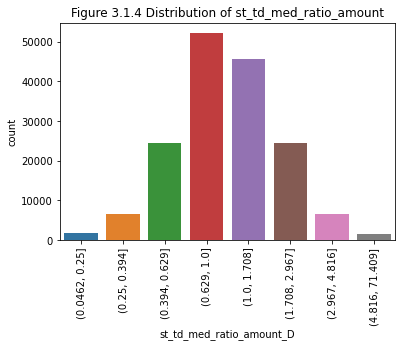

```python
# Plot the distribution
import matplotlib.pyplot as plt
plt.figure(figsize=(6,4))
g = sns.countplot(x='st_td_med_ratio_amount_D', data=df4)
g.set_xticklabels(g.get_xticklabels(), rotation=90)
plt.title('Figure 3.1.4 Distribution of st_td_med_ratio_amount')
```

##### Thought process:

- Now, we have identified extreme spending compared to the same state and total discharges.
- The ratio of total discharges by state and DRG category larger than 3 times of the median can be anomalies, and potential frauds.

```python
df4[df4['st_td_med_ratio_amount']>3].head()
```

|  | DRG | Provider_Id | Provider_Name | Provider_StreetAddress | Provider_City | Provider_State | Provider_Zipcode | Hospital_referral_region_desp | Total_Discharges | Average_Total_Payments | Average_Medicare_Payment | Total_Payments | Med_Dischs_ByStateDRG | st_td_med_ratio_amount | st_td_med_ratio_amount_D |
| --- | --- | --- | --- | --- | --- | --- | --- | --- | --- | --- | --- | --- | --- | --- | --- |
| 0 | 039 - EXTRACRANIAL PROCEDURES W/O CC/MCC | 10001 | SOUTHEAST ALABAMA MEDICAL CENTER | 1108 ROSS CLARK CIRCLE | DOTHAN | AL | 36301 | AL - Dothan | 91 | 5777.24 | 4763.73 | 525728.84 | 29.0 | 3.137931 | (2.967, 4.816] |
| 8 | 039 - EXTRACRANIAL PROCEDURES W/O CC/MCC | 10039 | HUNTSVILLE HOSPITAL | 101 SIVLEY RD | HUNTSVILLE | AL | 35801 | AL - Huntsville | 135 | 6113.38 | 5228.40 | 825306.30 | 29.0 | 4.655172 | (2.967, 4.816] |
| 35 | 039 - EXTRACRANIAL PROCEDURES W/O CC/MCC | 30061 | BANNER BOSWELL MEDICAL CENTER | 10401 WEST THUNDERBIRD BOULEVARD | SUN CITY | AZ | 85351 | AZ - Sun City | 62 | 6048.61 | 4951.90 | 375013.82 | 19.0 | 3.263158 | (2.967, 4.816] |
| 47 | 039 - EXTRACRANIAL PROCEDURES W/O CC/MCC | 30105 | BANNER HEART HOSPITAL | 6750 EAST BAYWOOD AVENUE | MESA | AZ | 85206 | AZ - Mesa | 64 | 6291.95 | 4788.12 | 402684.80 | 19.0 | 3.368421 | (2.967, 4.816] |
| 60 | 039 - EXTRACRANIAL PROCEDURES W/O CC/MCC | 40114 | BAPTIST HEALTH MEDICAL CENTER-LITTLE ROCK | 9601 INTERSTATE 630, EXIT 7 | LITTLE ROCK | AR | 72205 | AR - Little Rock | 139 | 5968.44 | 4592.46 | 829613.16 | 31.0 | 4.483871 | (2.967, 4.816] |

##### Conclusion:

- This feature identifies the anomalies by comparing a transaction amount to a median amount at the state and total discharges level. Here, those amounts which are more than 3 times of the median are determined to be the anomalies, and potential frauds.

#### 3.2.5 Feature 5: The ratio to average medicare payment by state and DRG

Back to Table of Content

##### My thought process:

- The ratio to average medicare payment by state and DRG is a good feature since hospitals which share the state and DRG are more likely to similar level of medical expense. If the ratio to average mdeicare amount of hospitals way above the average, we should check if it is anomolies.

```python
# add the new feature average spending to the dataset
df5 = pd.merge(data, benchmark5, how='left', on=['Provider_State', 'DRG'])
# Feature 5: ratio of amount spending and avergae medicare spending by state and DRG
df5['state_drg_avg_medi_ratio_amount'] = np.where(df5['Avg_Medi_ByStateDRG']==0, 0, df5['Average_Medicare_Payment'] / df5['Avg_Medi_ByStateDRG'])
df5['state_drg_avg_medi_ratio_amount'].describe()
```

```
count    163065.000000
mean          1.000000
std           0.215091
min           0.339831
25%           0.868395
50%           0.954250
75%           1.071483
max           5.174415
Name: state_drg_avg_medi_ratio_amount, dtype: float64
```

##### My thought process:

- The above percentile motivates me to cut by percentile for plotting
- I set the percentile as [0,0.01,0.05,0.2,0.5,0.8,0.95,0.99,1].

```python
# cut by percentile for plotting
var = 'state_drg_avg_medi_ratio_amount'
binned_var = var + '_D'
percentile = [0,0.01,0.05,0.2,0.5,0.8,0.95,0.99,1]
df5[binned_var] = pd.qcut(df5[var], percentile)
df5[['state_drg_avg_medi_ratio_amount_D']]
```

|  | state_drg_avg_medi_ratio_amount_D |
| --- | --- |
| 0 | (0.954, 1.111] |
| 1 | (0.954, 1.111] |
| 2 | (0.954, 1.111] |
| 3 | (0.849, 0.954] |
| 4 | (0.954, 1.111] |
| ... | ... |
| 163060 | (0.757, 0.849] |
| 163061 | (0.655, 0.757] |
| 163062 | (0.954, 1.111] |
| 163063 | (1.744, 5.174] |
| 163064 | (0.757, 0.849] |

163065 rows × 1 columns

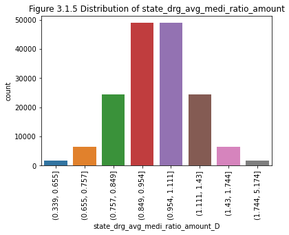

```python
# Plot the distribution
import matplotlib.pyplot as plt
plt.figure(figsize=(6,4))
g = sns.countplot(x='state_drg_avg_medi_ratio_amount_D', data=df5)
g.set_xticklabels(g.get_xticklabels(), rotation=90)
plt.title('Figure 3.1.5 Distribution of state_drg_avg_medi_ratio_amount')
```

##### My thought process:

- Now we have identified extreme spending compared to the same state and DRG.
- If the transactions are 2 times of the average, it should be anomalies since we can see from above description that standard deviation is high. Furthermore, the distribution plt indicates that there are a few in the far end. Therefore, above the 2 times of the average should be monitor to identified whether it is anomalies.

```python
df5[df5['state_drg_avg_medi_ratio_amount']>2].head()
```

|  | DRG | Provider_Id | Provider_Name | Provider_StreetAddress | Provider_City | Provider_State | Provider_Zipcode | Hospital_referral_region_desp | Total_Discharges | Average_Total_Payments | Average_Medicare_Payment | Total_Payments | Avg_Medi_ByStateDRG | state_drg_avg_medi_ratio_amount | state_drg_avg_medi_ratio_amount_D |
| --- | --- | --- | --- | --- | --- | --- | --- | --- | --- | --- | --- | --- | --- | --- | --- |
| 1172 | 057 - DEGENERATIVE NERVOUS SYSTEM DISORDERS W/... | 50276 | CONTRA COSTA REGIONAL MEDICAL CENTER | 2500 ALHAMBRA AVE | MARTINEZ | CA | 94553 | CA - Contra Costa County | 23 | 19239.30 | 18363.08 | 442503.90 | 7506.485256 | 2.446295 | (1.744, 5.174] |
| 1191 | 057 - DEGENERATIVE NERVOUS SYSTEM DISORDERS W/... | 50441 | STANFORD HOSPITAL | 300 PASTEUR DRIVE | STANFORD | CA | 94305 | CA - San Mateo County | 16 | 25519.43 | 22553.56 | 408310.88 | 7506.485256 | 3.004543 | (1.744, 5.174] |
| 1258 | 057 - DEGENERATIVE NERVOUS SYSTEM DISORDERS W/... | 100022 | JACKSON MEMORIAL HOSPITAL | 1611 NW 12TH AVE | MIAMI | FL | 33136 | FL - Miami | 29 | 12789.27 | 11467.62 | 370888.83 | 4759.258922 | 2.409539 | (1.744, 5.174] |
| 1417 | 057 - DEGENERATIVE NERVOUS SYSTEM DISORDERS W/... | 140150 | UNIVERSITY OF ILLINOIS HOSPITAL | 1740 WEST TAYLOR ST SUITE 1400 | CHICAGO | IL | 60612 | IL - Chicago | 16 | 12215.06 | 11442.81 | 195440.96 | 5428.791471 | 2.107801 | (1.744, 5.174] |
| 1554 | 057 - DEGENERATIVE NERVOUS SYSTEM DISORDERS W/... | 210009 | JOHNS HOPKINS HOSPITAL, THE | 600 NORTH WOLFE STREET | BALTIMORE | MD | 21287 | MD - Baltimore | 83 | 24865.61 | 22873.49 | 2063845.63 | 8352.411622 | 2.738549 | (1.744, 5.174] |

##### Conclusion:

- This feature identifies the anomalies by comparing a payment amount to an average amount of same the state and DGR. Here, those amounts more than 2 times the average are determined to be the anomalies, and potential frauds.

#### Feature 6: The ratio to median medicare payment by state and DRG

Back to Table of Content

##### My thought process:

- The ratio to median medicare payment by state and DRG is a good feature since hospitals which share the state and DRG are more likely to similar level of medical expense. Median is also crucial because average can be highly influenced by a small portion of extreme high or low value. If the ratio to median amount of hospitals way above the median, we should check if it is anomolies.

```python
# add the new feature average spending to the dataset
df6 = pd.merge(data, benchmark6, how='left', on=['Provider_State', 'DRG'])
# Feature 6: ratio of amount spending and avergae medicare spending by state and DRG
df6['state_drg_med_medi_ratio_amount'] = np.where(df6['Med_Medi_ByStateDRG']==0, 0, df6['Average_Medicare_Payment'] / df6['Med_Medi_ByStateDRG'])
df6['state_drg_med_medi_ratio_amount'].describe()
```

```
count    163065.000000
mean          1.055484
std           0.234139
min           0.367836
25%           0.916191
50%           1.000000
75%           1.121178
max           6.030981
Name: state_drg_med_medi_ratio_amount, dtype: float64
```

##### My thought process:

- The above percentile motivates me to cut by percentile for plotting
- I set the percentile as [0,0.01,0.05,0.2,0.5,0.8,0.95,0.99,1].

```python
# cut by percentile for plotting
var = 'state_drg_med_medi_ratio_amount'
binned_var = var + '_D'
percentile = [0,0.01,0.05,0.2,0.5,0.8,0.95,0.99,1]
df6[binned_var] = pd.qcut(df6[var], percentile)
df6[['state_drg_med_medi_ratio_amount_D']]
```

|  | state_drg_med_medi_ratio_amount_D |
| --- | --- |
| 0 | (1.0, 1.167] |
| 1 | (1.0, 1.167] |
| 2 | (0.897, 1.0] |
| 3 | (0.897, 1.0] |
| 4 | (1.0, 1.167] |
| ... | ... |
| 163060 | (0.805, 0.897] |
| 163061 | (0.714, 0.805] |
| 163062 | (1.167, 1.527] |
| 163063 | (1.898, 6.031] |
| 163064 | (0.805, 0.897] |

163065 rows × 1 columns

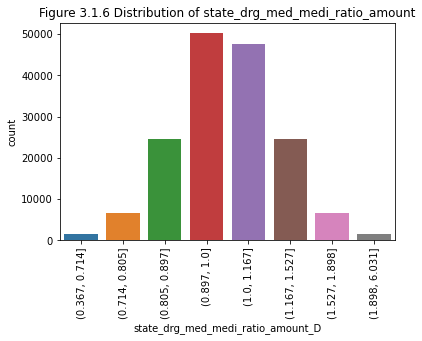

```python
# Plot the distribution
import matplotlib.pyplot as plt
plt.figure(figsize=(6,4))
g = sns.countplot(x='state_drg_med_medi_ratio_amount_D', data=df6)
g.set_xticklabels(g.get_xticklabels(), rotation=90)
plt.title('Figure 3.1.6 Distribution of state_drg_med_medi_ratio_amount')
```

##### Thought process:

- Now, we have identified extreme spending compared to the same state and DRG.
- The ratio of amount spending and median amount by state and DRG category larger than 2 times of the median can be anomalies.

```python
df6[df6['state_drg_med_medi_ratio_amount']>2].head()
```

|  | DRG | Provider_Id | Provider_Name | Provider_StreetAddress | Provider_City | Provider_State | Provider_Zipcode | Hospital_referral_region_desp | Total_Discharges | Average_Total_Payments | Average_Medicare_Payment | Total_Payments | Med_Medi_ByStateDRG | state_drg_med_medi_ratio_amount | state_drg_med_medi_ratio_amount_D |
| --- | --- | --- | --- | --- | --- | --- | --- | --- | --- | --- | --- | --- | --- | --- | --- |
| 456 | 039 - EXTRACRANIAL PROCEDURES W/O CC/MCC | 210029 | JOHNS HOPKINS BAYVIEW MEDICAL CENTER | 4940 EASTERN AVENUE | BALTIMORE | MD | 21224 | MD - Baltimore | 11 | 16878.45 | 15855.18 | 185662.95 | 7340.710 | 2.159897 | (1.898, 6.031] |
| 690 | 039 - EXTRACRANIAL PROCEDURES W/O CC/MCC | 330195 | LONG ISLAND JEWISH MEDICAL CENTER | 270 - 05 76TH AVENUE | NEW HYDE PARK | NY | 11040 | NY - East Long Island | 11 | 13895.09 | 13280.54 | 152845.99 | 6358.070 | 2.088769 | (1.898, 6.031] |
| 1172 | 057 - DEGENERATIVE NERVOUS SYSTEM DISORDERS W/... | 50276 | CONTRA COSTA REGIONAL MEDICAL CENTER | 2500 ALHAMBRA AVE | MARTINEZ | CA | 94553 | CA - Contra Costa County | 23 | 19239.30 | 18363.08 | 442503.90 | 6800.435 | 2.700280 | (1.898, 6.031] |
| 1186 | 057 - DEGENERATIVE NERVOUS SYSTEM DISORDERS W/... | 50376 | LAC/HARBOR-UCLA MED CENTER | 1000 W CARSON ST | TORRANCE | CA | 90509 | CA - Los Angeles | 13 | 15070.23 | 14381.00 | 195912.99 | 6800.435 | 2.114718 | (1.898, 6.031] |
| 1191 | 057 - DEGENERATIVE NERVOUS SYSTEM DISORDERS W/... | 50441 | STANFORD HOSPITAL | 300 PASTEUR DRIVE | STANFORD | CA | 94305 | CA - San Mateo County | 16 | 25519.43 | 22553.56 | 408310.88 | 6800.435 | 3.316488 | (1.898, 6.031] |

##### Conclusion:

- This feature identifies the anomalies by comparing a transaction amount to a median amount at the state and DRG level. Here, these amounts which are more than 2 times of the median are determined to be the anomalies, and potential frauds.

#### 3.2.7 Feature 7: The ratio to average payment by region and DRG

Back to Table of Content

##### My thought process:

- The ratio to average payment by region and DRG is a good feature since hospitals which share the region and DRG are more likely to similar level of medical expense. If the ratio to average amount of hospitals way above the average, we should check if it is anomolies.

```python
# add the new feature average spending to the dataset
df7 = pd.merge(data, benchmark7, how='left', on=['Hospital_referral_region_desp', 'DRG'])
# Feature 7: ratio of amount spending and avergae spending by region and DRG
df7['region_drg_avg_ratio_amount'] = np.where(df7['Avg_Pmts_ByRegionDRG']==0, 0, df7['Average_Total_Payments'] / df7['Avg_Pmts_ByRegionDRG'])
df7['region_drg_avg_ratio_amount'].describe()
```

```
count    163065.000000
mean          1.000000
std           0.159145
min           0.271255
25%           0.902856
50%           0.977701
75%           1.057561
max           4.848303
Name: region_drg_avg_ratio_amount, dtype: float64
```

##### My thought process:

- The above percentile motivates me to cut by percentile for plotting
- I set the percentile as [0,0.01,0.05,0.2,0.5,0.8,0.95,0.99,1].

```python
# cut by percentile for plotting
var = 'region_drg_avg_ratio_amount'
binned_var = var + '_D'
percentile = [0,0.01,0.05,0.2,0.5,0.8,0.95,0.99,1]
df7[binned_var] = pd.qcut(df7[var], percentile)
df7[['region_drg_avg_ratio_amount_D']]
```

|  | region_drg_avg_ratio_amount_D |
| --- | --- |
| 0 | (0.978, 1.085] |
| 1 | (0.978, 1.085] |
| 2 | (0.885, 0.978] |
| 3 | (0.885, 0.978] |
| 4 | (0.978, 1.085] |
| ... | ... |
| 163060 | (0.803, 0.885] |
| 163061 | (0.803, 0.885] |
| 163062 | (1.085, 1.305] |
| 163063 | (1.544, 4.848] |
| 163064 | (0.734, 0.803] |

163065 rows × 1 columns

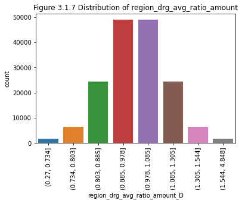

```python
# Plot the distribution
import matplotlib.pyplot as plt
plt.figure(figsize=(6,4))
g = sns.countplot(x='region_drg_avg_ratio_amount_D', data=df7)
g.set_xticklabels(g.get_xticklabels(), rotation=90)
plt.title('Figure 3.1.7 Distribution of region_drg_avg_ratio_amount')
```

##### My thought process:

- Now we have identified extreme spending compared to the same region and DRG.
- If the transactions are 2 times of the average, it should be anomalies since we can see from above description that standard deviation is high. Furthermore, the distribution plt indicates that there are a few in the far end. Therefore, above the 2 times of the average should be monitor to identified whether it is anomalies.

```python
df7[df7['region_drg_avg_ratio_amount']>2].head()
```

|  | DRG | Provider_Id | Provider_Name | Provider_StreetAddress | Provider_City | Provider_State | Provider_Zipcode | Hospital_referral_region_desp | Total_Discharges | Average_Total_Payments | Average_Medicare_Payment | Total_Payments | Avg_Pmts_ByRegionDRG | region_drg_avg_ratio_amount | region_drg_avg_ratio_amount_D |
| --- | --- | --- | --- | --- | --- | --- | --- | --- | --- | --- | --- | --- | --- | --- | --- |
| 1554 | 057 - DEGENERATIVE NERVOUS SYSTEM DISORDERS W/... | 210009 | JOHNS HOPKINS HOSPITAL, THE | 600 NORTH WOLFE STREET | BALTIMORE | MD | 21287 | MD - Baltimore | 83 | 24865.61 | 22873.49 | 2063845.63 | 10082.885500 | 2.466120 | (1.544, 4.848] |
| 1886 | 057 - DEGENERATIVE NERVOUS SYSTEM DISORDERS W/... | 330234 | WESTCHESTER MEDICAL CENTER | 100 WOODS RD | VALHALLA | NY | 10595 | NY - White Plains | 24 | 17129.08 | 16369.29 | 411097.92 | 8183.321818 | 2.093170 | (1.544, 4.848] |
| 2461 | 064 - INTRACRANIAL HEMORRHAGE OR CEREBRAL INFA... | 50348 | UNIVERSITY OF CALIFORNIA IRVINE MED CENTER | 101 CITY DRIVE SOUTH | ORANGE | CA | 92868 | CA - Orange County | 26 | 33918.23 | 33054.88 | 881873.98 | 16319.324286 | 2.078409 | (1.544, 4.848] |
| 2800 | 064 - INTRACRANIAL HEMORRHAGE OR CEREBRAL INFA... | 140150 | UNIVERSITY OF ILLINOIS HOSPITAL | 1740 WEST TAYLOR ST SUITE 1400 | CHICAGO | IL | 60612 | IL - Chicago | 16 | 38370.00 | 22039.37 | 613920.00 | 17973.993333 | 2.134751 | (1.544, 4.848] |
| 2992 | 064 - INTRACRANIAL HEMORRHAGE OR CEREBRAL INFA... | 210009 | JOHNS HOPKINS HOSPITAL, THE | 600 NORTH WOLFE STREET | BALTIMORE | MD | 21287 | MD - Baltimore | 64 | 50882.40 | 48632.28 | 3256473.60 | 18517.511579 | 2.747799 | (1.544, 4.848] |

##### Conclusion:

- This feature identifies the anomalies by comparing a payment amount to an average amount of same the region and DGR. Here, those amounts more than 2 times the average are determined to be the anomalies, and potential frauds.

Back to Table of Content

##### My thought process:

- The ratio to total discharges by region and DRG is a good feature since hospitals which share the region and DRG are more likely to similar level of total discharges. If the ratio to total discharges way above the average, we should check if it is anomolies.

```python
# add the new feature average spending to the dataset
df8 = pd.merge(data, benchmark8, how='left', on=['Hospital_referral_region_desp', 'DRG'])
# Feature 8: ratio of total discharges and avergae spending by region and total discharges
df8['region_td_avg_ratio_amount'] = np.where(df8['Tot_Dischs_ByRegionDRG']==0, 0, df8['Average_Medicare_Payment'] / df8['Tot_Dischs_ByRegionDRG'])
df8['region_td_avg_ratio_amount'] = df8['region_td_avg_ratio_amount'].fillna(-1)
df8['region_td_avg_ratio_amount'].describe()
```

```
count    163065.000000
mean        282.295107
std         339.061365
min           5.096757
25%         103.943778
50%         176.221056
75%         322.525338
max       11453.393333
Name: region_td_avg_ratio_amount, dtype: float64
```

##### My thought process:

- The above percentile motivates me to cut by percentile for plotting
- I set the percentile as [0,0.01,0.05,0.2,0.5,0.8,0.95,0.99,1].

```python
# cut by percentile for plotting
var = 'region_td_avg_ratio_amount'
binned_var = var + '_D'
percentile = [0,0.01,0.05,0.2,0.5,0.8,0.95,0.99,1]
df8[binned_var] = pd.qcut(df8[var],percentile)
df8[['region_td_avg_ratio_amount_D']]
```

|  | region_td_avg_ratio_amount_D |
| --- | --- |
| 0 | (52.691, 92.244] |
| 1 | (176.221, 375.469] |
| 2 | (92.244, 176.221] |
| 3 | (92.244, 176.221] |
| 4 | (176.221, 375.469] |
| ... | ... |
| 163060 | (52.691, 92.244] |
| 163061 | (52.691, 92.244] |
| 163062 | (92.244, 176.221] |
| 163063 | (176.221, 375.469] |
| 163064 | (92.244, 176.221] |

163065 rows × 1 columns

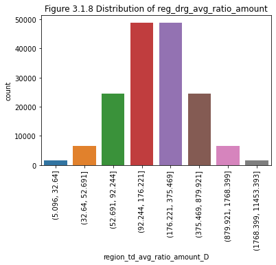

```python
# Plot the distribution
import matplotlib.pyplot as plt
plt.figure(figsize=(6,4))
g = sns.countplot(x='region_td_avg_ratio_amount_D', data=df8)
g.set_xticklabels(g.get_xticklabels(), rotation=90)
plt.title('Figure 3.1.8 Distribution of reg_drg_avg_ratio_amount')
```

##### Thought process:

- Now, we have identified extreme spending compared to the same region and DRG.
- The ratio of amount spending and average amount by name and DRG category larger than 880 times of the average can be anomalies, and potential frauds.

```python
df8[df8['region_td_avg_ratio_amount']>880].head()
```

|  | DRG | Provider_Id | Provider_Name | Provider_StreetAddress | Provider_City | Provider_State | Provider_Zipcode | Hospital_referral_region_desp | Total_Discharges | Average_Total_Payments | Average_Medicare_Payment | Total_Payments | Tot_Dischs_ByRegionDRG | region_td_avg_ratio_amount | region_td_avg_ratio_amount_D |
| --- | --- | --- | --- | --- | --- | --- | --- | --- | --- | --- | --- | --- | --- | --- | --- |
| 1172 | 057 - DEGENERATIVE NERVOUS SYSTEM DISORDERS W/... | 50276 | CONTRA COSTA REGIONAL MEDICAL CENTER | 2500 ALHAMBRA AVE | MARTINEZ | CA | 94553 | CA - Contra Costa County | 23 | 19239.30 | 18363.08 | 442503.90 | 17.25 | 1064.526377 | (879.921, 1768.399] |
| 1191 | 057 - DEGENERATIVE NERVOUS SYSTEM DISORDERS W/... | 50441 | STANFORD HOSPITAL | 300 PASTEUR DRIVE | STANFORD | CA | 94305 | CA - San Mateo County | 16 | 25519.43 | 22553.56 | 408310.88 | 16.00 | 1409.597500 | (879.921, 1768.399] |
| 2319 | 064 - INTRACRANIAL HEMORRHAGE OR CEREBRAL INFA... | 20012 | FAIRBANKS MEMORIAL HOSPITAL | 1650 COWLES STREET | FAIRBANKS | AK | 99701 | AK - Anchorage | 11 | 25443.00 | 24413.90 | 279873.00 | 22.50 | 1085.062222 | (879.921, 1768.399] |
| 2428 | 064 - INTRACRANIAL HEMORRHAGE OR CEREBRAL INFA... | 50228 | SAN FRANCISCO GENERAL HOSPITAL | 1001 POTRERO AVENUE | SAN FRANCISCO | CA | 94110 | CA - San Francisco | 19 | 35275.57 | 34455.00 | 670235.83 | 27.00 | 1276.111111 | (879.921, 1768.399] |
| 2434 | 064 - INTRACRANIAL HEMORRHAGE OR CEREBRAL INFA... | 50242 | DOMINICAN HOSPITAL | 1555 SOQUEL DRIVE | SANTA CRUZ | CA | 95065 | CA - Santa Cruz | 17 | 16705.64 | 15710.64 | 283995.88 | 17.00 | 924.155294 | (879.921, 1768.399] |

##### Conclusion:

- This feature identifies the anomalies by comparing the ratio to total discharges by the region and DRG level. Here, those amounts which are more than 880 times of the average are determined to be the anomalies, and potential frauds.

#### 3.2.9 Feature 9: The ratio to average medicare payment by region and DRG

Back to Table of Content

##### My thought process:

- The ratio to average medicare payment by region and DRG is a good feature since hospitals which share the region and DRG are more likely to similar level of medical expense. If the ratio to average mdeicare amount of hospitals way above the average, we should check if it is anomolies.

```python
# add the new feature average spending to the dataset
df9 = pd.merge(data, benchmark9, how='left', on=['Hospital_referral_region_desp', 'DRG'])
# Feature 5: ratio of amount spending and avergae medicare spending by state and DRG
df9['region_drg_avg_medi_ratio_amount'] = np.where(df9['Avg_Medi_Payment_ByRegionDRG']==0, 0, df9['Average_Medicare_Payment'] / df9['Avg_Medi_Payment_ByRegionDRG'])
df9['region_drg_avg_medi_ratio_amount'].describe()
```

```
count    163065.000000
mean          1.000000
std           0.175920
min           0.339831
25%           0.893506
50%           0.976954
75%           1.063344
max           4.516504
Name: region_drg_avg_medi_ratio_amount, dtype: float64
```

##### My thought process:

- The above percentile motivates me to cut by percentile for plotting
- I set the percentile as [0,0.01,0.05,0.2,0.5,0.8,0.95,0.99,1].

```python
# cut by percentile for plotting
var = 'region_drg_avg_medi_ratio_amount'
binned_var = var + '_D'
percentile = [0,0.01,0.05,0.2,0.5,0.8,0.95,0.99,1]
df9[binned_var] = pd.qcut(df9[var], percentile)
df9[['region_drg_avg_medi_ratio_amount_D']]
```

|  | region_drg_avg_medi_ratio_amount_D |
| --- | --- |
| 0 | (0.977, 1.093] |
| 1 | (0.977, 1.093] |
| 2 | (0.873, 0.977] |
| 3 | (0.873, 0.977] |
| 4 | (0.977, 1.093] |
| ... | ... |
| 163060 | (0.779, 0.873] |
| 163061 | (0.339, 0.7] |
| 163062 | (1.093, 1.337] |
| 163063 | (1.613, 4.517] |
| 163064 | (0.7, 0.779] |

163065 rows × 1 columns

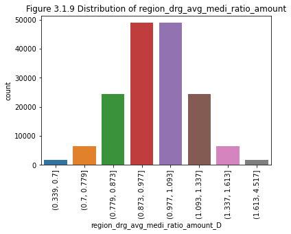

```python
# Plot the distribution
import matplotlib.pyplot as plt
plt.figure(figsize=(6,4))
g = sns.countplot(x='region_drg_avg_medi_ratio_amount_D', data=df9)
g.set_xticklabels(g.get_xticklabels(), rotation=90)
plt.title('Figure 3.1.9 Distribution of region_drg_avg_medi_ratio_amount')
```

##### My thought process:

```python
df9[df9['region_drg_avg_medi_ratio_amount']>2].head()
```

|  | DRG | Provider_Id | Provider_Name | Provider_StreetAddress | Provider_City | Provider_State | Provider_Zipcode | Hospital_referral_region_desp | Total_Discharges | Average_Total_Payments | Average_Medicare_Payment | Total_Payments | Avg_Medi_Payment_ByRegionDRG | region_drg_avg_medi_ratio_amount | region_drg_avg_medi_ratio_amount_D |
| --- | --- | --- | --- | --- | --- | --- | --- | --- | --- | --- | --- | --- | --- | --- | --- |
| 1554 | 057 - DEGENERATIVE NERVOUS SYSTEM DISORDERS W/... | 210009 | JOHNS HOPKINS HOSPITAL, THE | 600 NORTH WOLFE STREET | BALTIMORE | MD | 21287 | MD - Baltimore | 83 | 24865.61 | 22873.49 | 2063845.63 | 9017.156000 | 2.536663 | (1.613, 4.517] |
| 1566 | 057 - DEGENERATIVE NERVOUS SYSTEM DISORDERS W/... | 210029 | JOHNS HOPKINS BAYVIEW MEDICAL CENTER | 4940 EASTERN AVENUE | BALTIMORE | MD | 21224 | MD - Baltimore | 103 | 19700.60 | 18407.07 | 2029161.80 | 9017.156000 | 2.041339 | (1.613, 4.517] |
| 1886 | 057 - DEGENERATIVE NERVOUS SYSTEM DISORDERS W/... | 330234 | WESTCHESTER MEDICAL CENTER | 100 WOODS RD | VALHALLA | NY | 10595 | NY - White Plains | 24 | 17129.08 | 16369.29 | 411097.92 | 7279.557273 | 2.248666 | (1.613, 4.517] |
| 2138 | 057 - DEGENERATIVE NERVOUS SYSTEM DISORDERS W/... | 450018 | UNIVERSITY OF TEXAS MEDICAL BRANCH GAL | 301 UNIVERSITY BOULEVARD | GALVESTON | TX | 77555 | TX - Houston | 16 | 14123.06 | 13205.31 | 225968.96 | 6001.717143 | 2.200255 | (1.613, 4.517] |
| 2461 | 064 - INTRACRANIAL HEMORRHAGE OR CEREBRAL INFA... | 50348 | UNIVERSITY OF CALIFORNIA IRVINE MED CENTER | 101 CITY DRIVE SOUTH | ORANGE | CA | 92868 | CA - Orange County | 26 | 33918.23 | 33054.88 | 881873.98 | 15352.735714 | 2.153029 | (1.613, 4.517] |

##### Conclusion:

- This feature identifies the anomalies by comparing a payment amount to an average amount of same the region and DGR. Here, those amounts more than 2 times the average are determined to be the anomalies, and potential frauds.

#### 3.2.10 Feature 10: The ratio to total payment by region and DRG

Back to Table of Content

##### My thought process:

- The ratio to total payment by region and DRG is a good feature since hospitals which share the region and DRG are more likely to similar level of medical expense. If the ratio to total amount of hospitals way above the average, we should check if it is anomolies.

```python
# add the new feature average spending to the dataset

df10 = pd.merge(data, benchmark10, how='left', on=['Hospital_referral_region_desp', 'DRG'])
# Feature 7: ratio of amount spending and avergae spending by region and DRG
df10['region_drg_pmts_ratio_amount'] = np.where(df10['Tot_Pmts_ByRegionDRG']==0, 0, df10['Total_Payments'] / df10['Tot_Pmts_ByRegionDRG'])
df10['region_drg_pmts_ratio_amount'].describe()
```

```
count    163065.000000
mean          1.000000
std           0.640183
min           0.014374
25%           0.564201
50%           0.869294
75%           1.250038
max          10.197440
Name: region_drg_pmts_ratio_amount, dtype: float64
```

##### My thought process:

- The above percentile motivates me to cut by percentile for plotting
- I set the percentile as [0,0.01,0.05,0.2,0.5,0.8,0.95,0.99,1].

```python
# cut by percentile for plotting
var = 'region_drg_pmts_ratio_amount'
binned_var = var + '_D'
percentile = [0,0.01,0.05,0.2,0.5,0.8,0.95,0.99,1]
df10[binned_var] = pd.qcut(df10[var], percentile)
df10[['region_drg_pmts_ratio_amount_D']]
```

|  | region_drg_pmts_ratio_amount_D |
| --- | --- |
| 0 | (0.869, 1.378] |
| 1 | (0.507, 0.869] |
| 2 | (0.507, 0.869] |
| 3 | (0.507, 0.869] |
| 4 | (0.507, 0.869] |
| ... | ... |
| 163060 | (0.507, 0.869] |
| 163061 | (0.187, 0.3] |
| 163062 | (0.507, 0.869] |
| 163063 | (0.507, 0.869] |
| 163064 | (0.3, 0.507] |

163065 rows × 1 columns

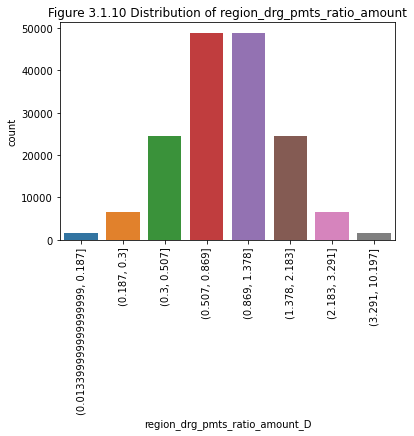

```python
# Plot the distribution
import matplotlib.pyplot as plt
plt.figure(figsize=(6,4))
g = sns.countplot(x='region_drg_pmts_ratio_amount_D', data=df10)
g.set_xticklabels(g.get_xticklabels(), rotation=90)
plt.title('Figure 3.1.10 Distribution of region_drg_pmts_ratio_amount')
```

##### My thought process:

- Now we have identified extreme spending compared to the same region and DRG.
- If the transactions are 2 times of the average, it should be anomalies since it only takes 5%. Furthermore, the distribution plt indicates that there are a few in the far end. Therefore, above the 2 times of the average should be monitor to identified whether it is anomalies.

```python
df10[df10['region_drg_pmts_ratio_amount']>2].head()
```

|  | DRG | Provider_Id | Provider_Name | Provider_StreetAddress | Provider_City | Provider_State | Provider_Zipcode | Hospital_referral_region_desp | Total_Discharges | Average_Total_Payments | Average_Medicare_Payment | Total_Payments | Tot_Pmts_ByRegionDRG | region_drg_pmts_ratio_amount | region_drg_pmts_ratio_amount_D |
| --- | --- | --- | --- | --- | --- | --- | --- | --- | --- | --- | --- | --- | --- | --- | --- |
| 21 | 039 - EXTRACRANIAL PROCEDURES W/O CC/MCC | 10113 | MOBILE INFIRMARY | 5 MOBILE INFIRMARY CIRCLE | MOBILE | AL | 36652 | AL - Mobile | 66 | 5550.90 | 4219.90 | 366359.40 | 166715.664000 | 2.197510 | (2.183, 3.291] |
| 33 | 039 - EXTRACRANIAL PROCEDURES W/O CC/MCC | 30030 | PHOENIX BAPTIST HOSPITAL | 2000 WEST BETHANY HOME ROAD | PHOENIX | AZ | 85015 | AZ - Phoenix | 42 | 7673.21 | 6541.92 | 322274.82 | 156931.058667 | 2.053608 | (1.378, 2.183] |
| 60 | 039 - EXTRACRANIAL PROCEDURES W/O CC/MCC | 40114 | BAPTIST HEALTH MEDICAL CENTER-LITTLE ROCK | 9601 INTERSTATE 630, EXIT 7 | LITTLE ROCK | AR | 72205 | AR - Little Rock | 139 | 5968.44 | 4592.46 | 829613.16 | 273109.015556 | 3.037663 | (2.183, 3.291] |
| 80 | 039 - EXTRACRANIAL PROCEDURES W/O CC/MCC | 50108 | SUTTER GENERAL HOSPITAL | 2801 L STREET | SACRAMENTO | CA | 95816 | CA - Sacramento | 67 | 8894.85 | 7905.65 | 595954.95 | 292199.565000 | 2.039548 | (1.378, 2.183] |
| 125 | 039 - EXTRACRANIAL PROCEDURES W/O CC/MCC | 50625 | CEDARS-SINAI MEDICAL CENTER | 8700 BEVERLY BLVD | LOS ANGELES | CA | 90048 | CA - Los Angeles | 40 | 9754.92 | 7705.97 | 390196.80 | 179916.134615 | 2.168770 | (1.378, 2.183] |

##### Conclusion:

- This feature identifies the anomalies by comparing a payment amount to an average amount of same the region and DGR. Here, those amounts more than 2 times the average are determined to be the anomalies, and potential frauds.

## Section 4: Unsupervised Machine Learning Techniques (PCA)

Back to Table of Content

### 4.1 Principal Component Analysis (PCA)

#### What is PCA?

- My thoughts: Principal Component Analysis (PCA) is the common technique of dimension reduction of a dataset consisting of a large number of related variables while retaining as much variance in the data as possible. At the same time, dimensionality reduction can also find outliers. The process is following. PCA transform features into less variables but remains the key important factors. After the transformation, the “normal” data points will align along the eigenvectors (new axes) with small eigenvalues. The outliers are far away from the eigenvectors with large eigenvalues. Therefore the distances between each data point to the eigenvectors become a measure for the outlier. A large distance indicates an anomaly.

```python
df1_key = df1.state_drg_avg_ratio_amount
df2_key = df2.state_drg_med_ratio_amount
df3_key = df3.st_td_avg_ratio_amount
df4_key = df4.st_td_med_ratio_amount
df5_key = df5.state_drg_avg_medi_ratio_amount
df6_key = df6.state_drg_med_medi_ratio_amount
df7_key = df7.region_drg_avg_ratio_amount
df8_key = df8.region_td_avg_ratio_amount
df9_key = df9.region_drg_avg_medi_ratio_amount
df10_key = df10.region_drg_pmts_ratio_amount
df = pd.concat([df1_key, df2_key, df3_key, df4_key, df5_key, df6_key, df7_key, df8_key, df9_key, df10_key],axis=1)
df.head()
df.shape
```

```
(163065, 10)
```

```python
# create a df with renamed columns
dd = pd.DataFrame(df)
# dd.columns = ['state_drg_avg_ratio_amount', 'state_drg_med_ratio_amount', 'st_td_avg_ratio_amount', 'st_td_med_ratio_amount',
#              'state_drg_avg_medi_ratio_amount', 'state_drg_med_medi_ratio_amount', 'region_drg_avg_ratio_amount',
#              'region_td_avg_ratio_amount', 'region_drg_avg_medi_ratio_amount', 'region_drg_pmts_ratio_amount']
dd.head()
```

|  | state_drg_avg_ratio_amount | state_drg_med_ratio_amount | st_td_avg_ratio_amount | st_td_med_ratio_amount | state_drg_avg_medi_ratio_amount | state_drg_med_medi_ratio_amount | region_drg_avg_ratio_amount | region_td_avg_ratio_amount | region_drg_avg_medi_ratio_amount | region_drg_pmts_ratio_amount |
| --- | --- | --- | --- | --- | --- | --- | --- | --- | --- | --- |
| 0 | 1.005855 | 1.021015 | 124.648225 | 3.137931 | 1.035685 | 1.065311 | 1.037810 | 70.054853 | 1.038763 | 1.371297 |
| 1 | 1.007653 | 1.022841 | 130.221081 | 0.482759 | 1.081989 | 1.112940 | 1.008540 | 181.224734 | 1.080948 | 0.508808 |
| 2 | 0.946260 | 0.960522 | 116.538305 | 0.827586 | 0.968301 | 0.995999 | 0.947092 | 162.182829 | 0.967369 | 0.819100 |
| 3 | 0.943232 | 0.957449 | 108.044005 | 0.862069 | 0.897723 | 0.923402 | 0.944062 | 150.361569 | 0.896859 | 0.850499 |
| 4 | 0.985152 | 1.000000 | 126.943254 | 0.620690 | 1.054754 | 1.084926 | 0.986018 | 176.663081 | 1.053739 | 0.639574 |

```python
# check NA
dd.isnull().sum()
```

```
state_drg_avg_ratio_amount          0
state_drg_med_ratio_amount          0
st_td_avg_ratio_amount              0
st_td_med_ratio_amount              0
state_drg_avg_medi_ratio_amount     0
state_drg_med_medi_ratio_amount     0
region_drg_avg_ratio_amount         0
region_td_avg_ratio_amount          0
region_drg_avg_medi_ratio_amount    0
region_drg_pmts_ratio_amount        0
dtype: int64
```

```python
# !pip3 install pyod
# !pip install --upgrade pyod
import warnings
warnings.simplefilter(action='ignore', category=UserWarning)
import numpy as np
import pandas as pd
import matplotlib.pyplot as plt
from sklearn.model_selection import train_test_split
```

```python
# cut data for ease of computation intensity
X = dd.sample(frac=.2, replace=False, random_state=23)
X.shape
```

```
(32613, 10)
```

```python
# split data into train and test
X_train, X_test = train_test_split(X, train_size=0.8, random_state=23)
X_train.head()
```

|  | state_drg_avg_ratio_amount | state_drg_med_ratio_amount | st_td_avg_ratio_amount | st_td_med_ratio_amount | state_drg_avg_medi_ratio_amount | state_drg_med_medi_ratio_amount | region_drg_avg_ratio_amount | region_td_avg_ratio_amount | region_drg_avg_medi_ratio_amount | region_drg_pmts_ratio_amount |
| --- | --- | --- | --- | --- | --- | --- | --- | --- | --- | --- |
| 159234 | 1.054991 | 1.123816 | 437.043872 | 1.611111 | 1.079933 | 1.142101 | 1.041725 | 311.169250 | 1.030274 | 1.033062 |
| 150291 | 1.018665 | 1.057939 | 1936.072857 | 0.882353 | 0.842655 | 0.835367 | 1.018665 | 1936.072857 | 0.842655 | 0.682862 |
| 9026 | 1.232722 | 1.302428 | 105.771057 | 1.333333 | 1.265674 | 1.352009 | 1.234366 | 99.816716 | 1.289895 | 1.424701 |
| 76329 | 0.940920 | 0.949089 | 94.318809 | 1.014925 | 0.880921 | 0.877518 | 0.928128 | 68.661455 | 0.894147 | 0.540250 |
| 84392 | 0.965711 | 0.975612 | 58.014388 | 0.765957 | 0.853674 | 0.862074 | 1.000000 | 126.000000 | 1.000000 | 1.000000 |

```python
# In the interest of preventing information about the distribution of the test set
# leaking into your model, I standardize dataset after splitting
from sklearn.preprocessing import StandardScaler
scaler = StandardScaler()
X_train_scaled = scaler.fit_transform(X_train)
X_test_scaled = scaler.transform(X_test)
```

### 4.1.1 Build my model

Back to Table of Content

```python
# train PCA detector
from pyod.models.pca import PCA
from datetime import datetime

start=datetime.now()
clf_name = 'PCA'
clf = PCA()
clf.fit(X_train)
# If you want to see the predictions of the training data, you can use this way:
y_train_scores = clf.decision_scores_
print(y_train_scores[:5])
print(datetime.now()-start)
```

```
[ 5497.05502956 29449.4194984  13943.78007281  7793.26594796
  6983.45427374]
0:00:00.046331
```

```python
y_train_pred = clf.predict(X_train_scaled) # outlier labels (0 or 1)
unique, counts = np.unique(y_train_pred, return_counts=True)
print(dict(zip(unique, counts)))
pd.DataFrame(clf.labels_).value_counts()
```

```
{0: 576, 1: 25514}
```

```
0    23481
1     2609
dtype: int64
```

```python
start=datetime.now()
# Now we have the trained PCA model, let's apply to the test data to get the predictions
y_test_pred = clf.predict(X_test) # outlier labels (0 or 1)
# Because it is '0' and '1', we can run a count statistic. There are 661 '1's and 5862 '0's. The number of anomalies is roughly ten percent, as we have generated before:
unique, counts = np.unique(y_test_pred, return_counts=True)
print(dict(zip(unique, counts)))
# {0: 5862, 1: 661}
# And you can generate the anomaly score using clf.decision_function:
y_test_scores = clf.decision_function(X_test)
print(y_test_scores)
print(datetime.now()-start)
```

```
{0: 5862, 1: 661}
[6526.05313442 5749.30921642 9539.78256102 ... 8992.3131299  6625.46159681
 5737.03198332]
0:00:00.010047
```

- My thoughts: The function decision_functions() generates the anomaly score based on your model predictions. The PCA model uses the Euclidean distance to measure the distance. Since an outlier is the point that is distant from eigenvectors with large eigenvalue, the outlier score is defined as the distance to its eigenvectors. Each point will have an outlier score. Our job is to find those points with high outlier scores.

### 4.1.2 Determine a reasonable boundary

Back to Table of Content

|  | 0 |
| --- | --- |
| count | 6523.000000 |
| mean | 10793.016294 |
| std | 6903.913139 |
| min | 3808.925899 |
| 25% | 6863.332372 |
| 50% | 8674.035894 |
| 75% | 11876.472782 |
| max | 94238.808870 |

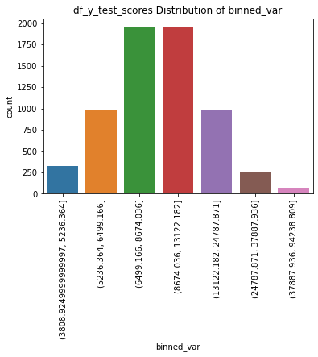

```python
# convert y_test_scores (outlier score) into df
display(pd.DataFrame(y_test_scores).describe())
# check the distritbution of y_test_scores (outlier score)
df_y_test_scores = pd.DataFrame(y_test_scores)
df_y_test_scores.rename(columns={0: 'bins'}, inplace=True)
percentile = [0,0.05,0.2,0.5,0.8,0.95,0.99,1]
df_y_test_scores['binned_var'] = pd.qcut(df_y_test_scores['bins'], percentile, duplicates='drop')
# Plot the distribution
import matplotlib.pyplot as plt
plt.figure(figsize=(6,4))
g = sns.countplot(x="binned_var", data=df_y_test_scores)
g.set_xticklabels(g.get_xticklabels(), rotation=90)
plt.title('df_y_test_scores Distribution of binned_var')
```

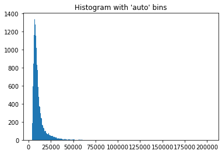

```python
# plot the graph based on the df and distribution
import matplotlib.pyplot as plt
# bins = 'auto', 'fd', 'doane', 'scott', 'stone', 'rice', 'sturges', or 'sqrt'
plt.hist(y_train_scores, bins='auto')  # arguments are passed to np.histogram
plt.title("Histogram with 'auto' bins")
plt.show()
```

- My thoughts: From the describe of the outlier score dataframe, 11876.47 is in the 75% of the dataset. On the other hand, the mean is higher than medium, which indicates that there are a few extreme high values. (The max value validates the assumption) From the distribution of the outlier score, 95% of the dataset is under 24787.87. A data point with a high anomaly score is abnormal. We can use a histogram to find those points. In histogram plot, we have 'auto' as X-axis bins. The histogram shows the count by the anomaly score. Most of the data points have low anomaly scores. If we choose 24787 to be the cut point, we can suggest those >= 24787 to be outliers. (We use the anomaly scores of the training data to determine the boundary.)

### 4.1.3. Present the summary statistics of the normal and abnormal clusters

Back to Table of Content

```python
# Let's see how many '0's and '1's. We get 452 '0's and 48 '1's.
df_test = pd.DataFrame(X_test_scaled)
df_test['score'] = y_test_scores
df_test['cluster'] = np.where(df_test['score']<24787, 0, 1)
df_test['cluster'].value_counts()
# Now let's show the summary statistics:
# df_test.groupby('y_by_average_cluster').mean()
df_test.columns = ['state_drg_avg_ratio_amount', 'state_drg_med_ratio_amount', 'st_td_avg_ratio_amount', 'st_td_med_ratio_amount',
             'state_drg_avg_medi_ratio_amount', 'state_drg_med_medi_ratio_amount', 'region_drg_avg_ratio_amount',
             'region_td_avg_ratio_amount', 'region_drg_avg_medi_ratio_amount', 'region_drg_pmts_ratio_amount', 'score', 'cluster']
display(df_test.groupby('cluster').mean())
df_test.cluster.value_counts()
```

| cluster | state_drg_avg_ratio_amount | state_drg_med_ratio_amount | st_td_avg_ratio_amount | st_td_med_ratio_amount | state_drg_avg_medi_ratio_amount | state_drg_med_medi_ratio_amount | region_drg_avg_ratio_amount | region_td_avg_ratio_amount | region_drg_avg_medi_ratio_amount | region_drg_pmts_ratio_amount | score |
| --- | --- | --- | --- | --- | --- | --- | --- | --- | --- | --- | --- |
| 0 | -0.128019 | -0.13004 | -0.088893 | -0.028405 | -0.121404 | -0.126306 | -0.129264 | -0.091940 | -0.120249 | -0.051702 | 9594.607320 |
| 1 | 2.201995 | 2.20867 | 1.992108 | 0.636170 | 2.155957 | 2.217313 | 2.049892 | 1.950084 | 1.990400 | 1.034236 | 33500.484192 |

```
0    6196
1     327
Name: cluster, dtype: int64
```

```python
from pyod.utils.utility import standardizer
import warnings
warnings.simplefilter(action='ignore')
# standardizer(X_train, X_test)
# X_test.drop(['score', 'cluster'], axis=1, inplace=True)
X_test.shape
```

```
(6523, 10)
```

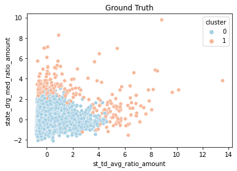

```python
# take st_td_avg_ratio_amount and state_drg_med_ratio_amount in score as an example
sns.scatterplot(x='st_td_avg_ratio_amount', y='state_drg_med_ratio_amount', hue='cluster', data=df_test, palette='RdBu_r');
plt.title('Ground Truth');
```

- My thoughts: I use st_td_avg_ratio_amount (x) and state_drg_med_ratio_amount (y) classified by cluster in df_test to plot the scatter graph. From the scatter graph above, orange dots are anmalies while blue dots are normal obsercations. Those are far away from eigenvectors with large eigenvalues are identified as anomalies.

```python
# clf = PCA(n_components=10)
# clf.fit(X_train)
```

[output not shown]

```python
from pyod.models.combination import aom, moa, average, maximization
from pyod.utils.utility import standardizer

start=datetime.now()
# Standardize data
X_train_norm, X_test_norm = standardizer(X_train, X_test)
# Test a range of k-neighbors from 10 to 200. There will be 20 k-NN models.
n_clf = 10
k_list = [1, 2, 3, 4, 5, 6, 7, 8, 9, 10]
# Just prepare data frames so we can store the model results
train_scores = np.zeros([X_train.shape[0], n_clf])
test_scores = np.zeros([X_test.shape[0], n_clf])
train_scores.shape
# Modeling
for i in range(n_clf):
    k = k_list[i]
    clf = PCA(n_components=k)
    clf.fit(X_train_norm)

    # Store the results in each column:
    train_scores[:, i] = clf.decision_scores_
    test_scores[:, i] = clf.decision_function(X_test_norm)
# Decision scores have to be normalized before combination
%time train_scores_norm, test_scores_norm = standardizer(train_scores,test_scores)
print(datetime.now()-start)
```

```
Wall time: 6.7 ms
0:00:00.378635
```

### Method 1: Average

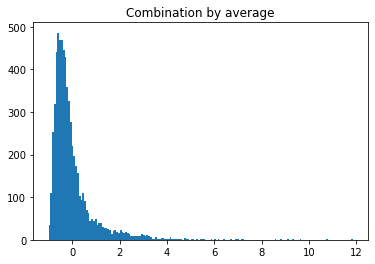

```python
# Combination by average
# The test_scores_norm is 500 x 20. The "average" function will take the average of the 20 columns. The result "y_by_average" is a single column:
y_by_average = average(test_scores_norm)

import matplotlib.pyplot as plt
# ax = plt.gca()
# ax.set_xlim([0, 42])
# ax.set_ylim([0, 100])
plt.hist(y_by_average, bins='auto')  # arguments are passed to np.histogram
plt.title("Combination by average")
plt.show()
```

```python
df_test = pd.DataFrame(X_test)
df_test['y_by_average_score'] = y_by_average
df_test['y_by_average_cluster'] = np.where(df_test['y_by_average_score']<3, 0, 1)
df_test['y_by_average_cluster'].value_counts()
```

```
0    6392
1     131
Name: y_by_average_cluster, dtype: int64
```

```python
df_test.groupby('y_by_average_cluster').mean()
```

[output not shown]

### Method 2: The Maximum of Maximum (MOM)

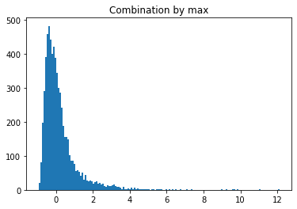

```python
# Combination by mom
y_by_maximization = maximization(test_scores_norm)

import matplotlib.pyplot as plt
plt.hist(y_by_maximization, bins='auto')  # arguments are passed to np.histogram
plt.title("Combination by max")
plt.show()
```

```python
df_test = pd.DataFrame(X_test)
df_test['y_by_maximization_score'] = y_by_maximization
df_test['y_by_maximization_cluster'] = np.where(df_test['y_by_maximization_score']<3, 0, 1)
df_test['y_by_maximization_cluster'].value_counts()
```

```
0    6371
1     152
Name: y_by_maximization_cluster, dtype: int64
```

```python
df_test.groupby('y_by_maximization_cluster').mean()
```

| y_by_maximization_cluster | state_drg_avg_ratio_amount | state_drg_med_ratio_amount | st_td_avg_ratio_amount | st_td_med_ratio_amount | state_drg_avg_medi_ratio_amount | state_drg_med_medi_ratio_amount | region_drg_avg_ratio_amount | region_td_avg_ratio_amount | region_drg_avg_medi_ratio_amount | region_drg_pmts_ratio_amount | y_by_average_score | y_by_average_cluster | y_by_maximization_score |
| --- | --- | --- | --- | --- | --- | --- | --- | --- | --- | --- | --- | --- | --- |
| 0 | 0.984450 | 1.033542 | 254.489666 | 1.244387 | 0.984411 | 1.037955 | 0.986752 | 266.299434 | 0.986945 | 0.981901 | -0.100207 | 0.000000 | 0.087144 |
| 1 | 1.528489 | 1.634783 | 1051.128090 | 2.072058 | 1.555945 | 1.676590 | 1.405946 | 1152.533136 | 1.427561 | 1.806483 | 4.137761 | 0.861842 | 4.281719 |

### Method 3: The Average of Maximum (AOM)`

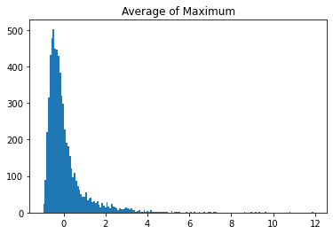

```python
# Combination by aom
y_by_aom = aom(test_scores_norm, n_buckets=5)

import matplotlib.pyplot as plt
plt.hist(y_by_aom, bins='auto')  # arguments are passed to np.histogram
plt.title("Average of Maximum")
plt.show()
```

```python
df_test = pd.DataFrame(X_test)
df_test['y_by_aom_score'] = y_by_aom
df_test['y_by_aom_cluster'] = np.where(df_test['y_by_aom_score']<3, 0, 1)
df_test['y_by_aom_cluster'].value_counts()
```

```
0    6378
1     145
Name: y_by_aom_cluster, dtype: int64
```

```python
df_test.groupby('y_by_aom_cluster').mean()
```

| y_by_aom_cluster | state_drg_avg_ratio_amount | state_drg_med_ratio_amount | st_td_avg_ratio_amount | st_td_med_ratio_amount | state_drg_avg_medi_ratio_amount | state_drg_med_medi_ratio_amount | region_drg_avg_ratio_amount | region_td_avg_ratio_amount | region_drg_avg_medi_ratio_amount | region_drg_pmts_ratio_amount | y_by_average_score | y_by_average_cluster | y_by_maximization_score | y_by_maximization_cluster | y_by_aom_score |
| --- | --- | --- | --- | --- | --- | --- | --- | --- | --- | --- | --- | --- | --- | --- | --- |
| 0 | 0.984897 | 1.034043 | 255.224115 | 1.244040 | 0.984946 | 1.038557 | 0.987134 | 267.025105 | 0.987406 | 0.981920 | -0.096930 | 0.000000 | 0.090374 | 0.001098 | -0.039949 |
| 1 | 1.535074 | 1.641799 | 1057.280883 | 2.127294 | 1.560034 | 1.680973 | 1.409391 | 1163.397298 | 1.428542 | 1.845431 | 4.198214 | 0.903448 | 4.342115 | 1.000000 | 4.252602 |

### Method 4: The maximum of average (MOA)

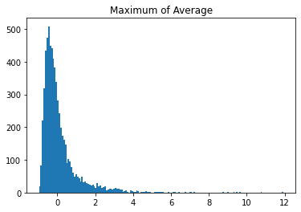

```python
# Combination by moa
y_by_moa = moa(test_scores_norm, n_buckets=5)

import matplotlib.pyplot as plt
plt.hist(y_by_moa, bins='auto')  # arguments are passed to np.histogram
plt.title("Maximum of Average")
plt.show()
```

```python
df_test = pd.DataFrame(X_test)
df_test['y_by_moa_score'] = y_by_moa
df_test['y_by_moa_cluster'] = np.where(df_test['y_by_moa_score']<3, 0, 1)
df_test['y_by_moa_cluster'].value_counts()
```

```
0    6376
1     147
Name: y_by_moa_cluster, dtype: int64
```

```python
df_test.groupby('y_by_moa_cluster').mean()
```

| y_by_moa_cluster | state_drg_avg_ratio_amount | state_drg_med_ratio_amount | st_td_avg_ratio_amount | st_td_med_ratio_amount | state_drg_avg_medi_ratio_amount | state_drg_med_medi_ratio_amount | region_drg_avg_ratio_amount | region_td_avg_ratio_amount | region_drg_avg_medi_ratio_amount | region_drg_pmts_ratio_amount | y_by_average_score | y_by_average_cluster | y_by_maximization_score | y_by_maximization_cluster | y_by_aom_score | y_by_aom_cluster | y_by_moa_score |
| --- | --- | --- | --- | --- | --- | --- | --- | --- | --- | --- | --- | --- | --- | --- | --- | --- | --- |
| 0 | 0.984776 | 1.033908 | 254.877074 | 1.243942 | 0.984796 | 1.038385 | 0.987066 | 266.740942 | 0.987317 | 0.981759 | -0.097880 | 0.000000 | 0.089455 | 0.000784 | -0.040899 | 0.000000 | -0.003072 |
| 1 | 1.532844 | 1.639390 | 1061.421147 | 2.119508 | 1.558704 | 1.679684 | 1.406582 | 1163.527090 | 1.426390 | 1.840697 | 4.180973 | 0.891156 | 4.324119 | 1.000000 | 4.235372 | 0.986395 | 4.260247 |